# Gender stereotypes in image recognition systems - Replication study of an algorithm audit

Author: Philipp Penner Based on the analysis of Carsten Schwemmer and Emily D. Bello-Pardo - Replication Data for: Diagnosing Gender Bias in Image Recognition Systems https://doi.org/10.7910/DVN/2CEYWV

10.10.2023

# 1 Introduction

This script is divided into the analysis of the original study and the analysis of the replication study. Slight adjustments and extensions were made in the script of the original study. The reasons for the adjustments and extensions can be found in the written elaboration.

For intersubjective traceability, all materials used in the replication study can be viewed in a GitHub repository. All R scripts, datasets, and figures are available at the following link:

https://github.com/Philipp-D-P/Replication-Gender-Bias-Image-Recognition

# 2 Software Setup

We use the following R packages and versions throughout the document:

```r
library(MASS)
library(tidyverse)
library(extrafont)
library(sjPlot)
library(magick)
library(ggrepel)
library(cowplot)
library(ggeffects)
library(effects)
library(hrbrthemes)
library(stargazer)
library(lubridate)
library(tidytext)
library(quanteda)
library(AER)
library(viridis)
library(scales)
library(DescTools)
library(imgrec)
library(stargazer)
library(mfx)
library(statmod)


loadfonts()
theme_set(theme_ipsum(base_size = 14,
                      axis_title_size = 14,
                      grid = 'XY'))
```

# 3 Original

## 3.1 Data Import and Overview

First, we load data of MCs and image annotations for their professional photographs which we extracted from their Wikipedia pages.

```r
mc_df <- read_tsv("data/mc_data.tsv")
head(mc_df)
```

```
## # A tibble: 6 x 16
##   name      age gender ethnicity type  party state user_screen_name wikipedia_id
##   <chr>   <dbl> <chr>  <chr>     <chr> <chr> <chr> <chr>            <chr>
## 1 Sherro~    66 Male   white     Sena~ Demo~ OH    SenSherrodBrown  Sherrod_Bro~
## 2 Maria ~    60 Female white     Sena~ Demo~ WA    SenatorCantwell  Maria_Cantw~
## 3 Benjam~    75 Male   white     Sena~ Demo~ MD    SenatorCardin    Ben_Cardin
## 4 Thomas~    71 Male   white     Sena~ Demo~ DE    SenatorCarper    Tom_Carper
## 5 Robert~    58 Male   white     Sena~ Demo~ PA    SenBobCasey      Bob_Casey_J~
## 6 Bob Co~    66 Male   white     Sena~ Repu~ TN    SenBobCorker     Bob_Corker
## # i 7 more variables: wiki_img_url <chr>, wiki_img_labels <chr>,
## #   wiki_img_labelsconf <chr>, wiki_img_labels_macv <chr>,
## #   wiki_img_labels_awsrek <chr>, wiki_img_labelsconf_awsrek <chr>,
## #   wiki_img_objects <chr>
```

The following chunk provides some descriptive statistics about the composition of this dataset.

```r
mc_df %>% count(party)
```

```
## # A tibble: 3 x 2
##   party           n
##   <chr>       <int>
## 1 Democrat      243
## 2 Independent     2
## 3 Republican    295
```

```r
mc_df %>% filter(party == "Independent")
```

```
## # A tibble: 2 x 16
##   name      age gender ethnicity type  party state user_screen_name wikipedia_id
##   <chr>   <dbl> <chr>  <chr>     <chr> <chr> <chr> <chr>            <chr>
## 1 Bernar~    77 Male   white     Sena~ Inde~ VT    SenSanders       Bernie_Sand~
## 2 Angus ~    74 Male   white     Sena~ Inde~ ME    SenAngusKing     Angus_King
## # i 7 more variables: wiki_img_url <chr>, wiki_img_labels <chr>,
## #   wiki_img_labelsconf <chr>, wiki_img_labels_macv <chr>,
## #   wiki_img_labels_awsrek <chr>, wiki_img_labelsconf_awsrek <chr>,
## #   wiki_img_objects <chr>
```

```r
mc_df %>% count(gender)
```

```
## # A tibble: 2 x 2
##   gender     n
##   <chr>  <int>
## 1 Female   110
## 2 Male     430
```

```r
mean(mc_df$age)
```

```
## [1] 60.42593
```

```r
mc_df %>% group_by(gender) %>% summarise(age = mean(age))
```

```
## # A tibble: 2 x 2
##   gender   age
##   <chr>  <dbl>
## 1 Female  62.2
## 2 Male    60.0
```

```r
summary(mc_df$age)
```

```
##    Min. 1st Qu.  Median    Mean 3rd Qu.    Max.
##   34.00   53.00   61.00   60.43   68.00   89.00
```

```r
prop.table(table(mc_df$party)) * 100
```

```
##
##    Democrat Independent  Republican
##  45.0000000   0.3703704  54.6296296
```

As we see above, there are 243 Democrats, 295 Republicans, and 2 Independents. There are 110 women and 430 men. The average age in this dataset is 60.43, with the average age among women being 62.24 and the average age among men being 59.96.

Get total number of labels

```r
# Function to count the total number of words in the column
total_word_count <- sum(sapply(mc_df$wiki_img_labels, function(text) length(strsplit(text, ", ")[[1]])))

# Show total number of words
print(total_word_count)
```

```
## [1] 5657
```

```r
# Number of labels for each person/image
total_word_count/540
```

```
## [1] 10.47593
```

## 3.2 Annotation examples

In the following, we provide examples of image annotations by Google Cloud Vision (GCV).

### 3.2.1 GCV Example

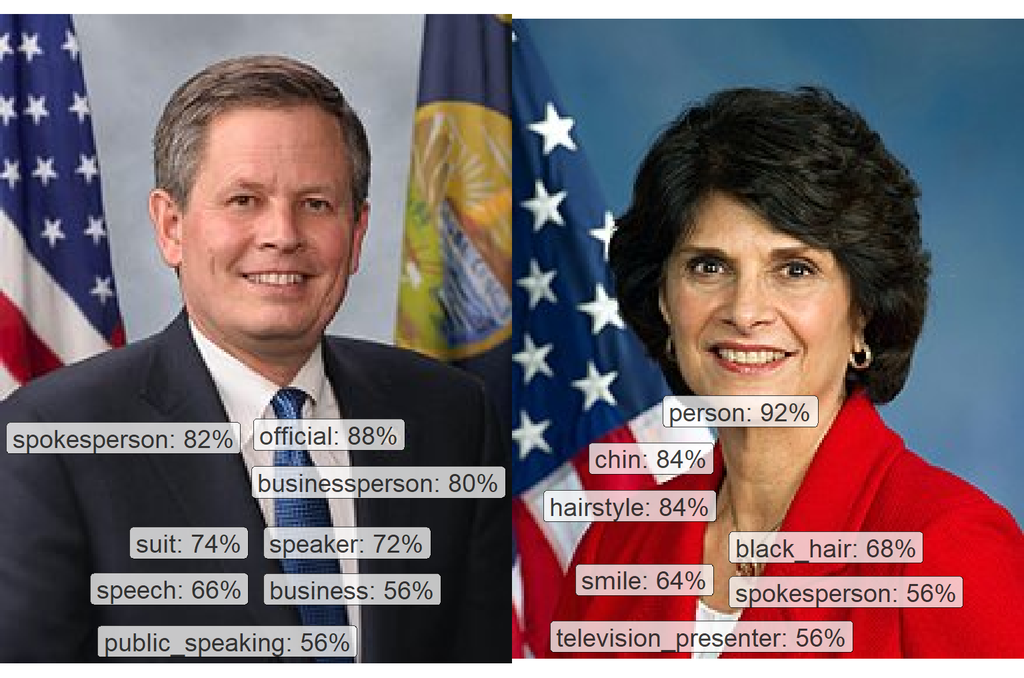

```r
# filtering and reshaping data
img_example1 <-
  mc_df %>% filter(str_detect(wiki_img_url, 'Steve_Daines|Lucille_Roybal')) %>%
  mutate(label = str_split(wiki_img_labels, ', '),
         score = str_split(wiki_img_labelsconf, ', ')) %>%
  unnest(c(label, score)) %>%
  mutate(score = round(as.numeric(score), 2)) %>%
  group_by(name) %>%
  mutate(pixel = score * 200) %>% # for visulization purposes
  dplyr::select(name, gender, party, label, score, pixel, wiki_img_url)

# creating plot
daines <-
  image_read('mc_images/Steve_Daines.jpg') %>%
  image_ggplot() +

  geom_label_repel(
    data = img_example1 %>% filter(name == 'Steve Daines'),
    aes(
      y = pixel - 90 ,
      x =  110,
      label = str_c(label, ': ', percent(score, accuracy = 2))
    ),
    direction = 'both',
    force = 20,
    segment.alpha = 0.00,
    size = 5,
    alpha = 0.75,
    seed = 2
  ) + guides(size = FALSE)


# creating plot
allard <- image_read('mc_images/Lucille_Roybal-Allard.jpg') %>%
  image_ggplot() +

  geom_label_repel(
    data = img_example1 %>% filter(name == 'Lucille Roybal-Allard'),
    aes(
      y = pixel - 90 ,
      x =  90,
      label = str_c(label, ': ', percent(score,  accuracy = 2))
    ),
    direction = 'both',
    force = 5,
    segment.alpha = 0.00,
    size = 5,
    alpha = 0.75,
    seed = 1337
  ) + guides(size = FALSE)

# combining plots
comb1 <- cowplot::plot_grid(daines, allard, labels = NULL)
comb1
```

```r
# ggsave(
#  'figures/example_annotations.png',
#  comb1,
#  dpi = 300,
#  width = 8,
#  height = 5.3
# )
```

## 3.3 Image labels - key differences

Next, we quantify key differences in labels by gender for GCV. We only consider labels that were assigned at least 5 times across all images.

```r
gcv_dfm <- corpus(mc_df,
                  text_field = 'wiki_img_labels',
                  docid_field = 'wikipedia_id') %>%
  dfm(remove_punct = TRUE) %>%
  dfm_trim(min_termfreq = 5)

dim(gcv_dfm)
```

```
## [1] 540  61
```

We create a function to examine group differences based on Chi² tests.

```r
key_diff <- function(featmat, groups,
                     groups1_name,
                     groups2_name,
                     group1_obs, group2_obs) {
  # grouping
  img_grouped <- dfm_group(featmat, groups = groups)


  # compute key labels for group 1
  key1 <- textstat_keyness(img_grouped,  target = groups1_name, measure = 'chi2')
  group_key1 <-
  key1 %>% mutate(
    groups = if_else(chi2 >= 0, groups1_name, groups2_name),
    key = groups1_name,
    chi2_abs = abs(chi2),
    obs_total = group1_obs
  ) %>%
  group_by(groups) %>% top_n(n = 25, wt = chi2_abs) %>% ungroup()

  # compute key labels for group 2
  key2 <- textstat_keyness(img_grouped,  target = groups2_name, measure = 'chi2')
  group_key2 <-
  key2 %>% mutate(
    groups = if_else(chi2 >= 0, groups2_name, groups1_name),
    key = groups2_name,
    chi2_abs = abs(chi2),
    obs_total = group2_obs
  ) %>%
  group_by(groups) %>% top_n(n = 25, wt = chi2_abs) %>% ungroup()


  # combine data and add frequency indicators
comb_key <- group_key1 %>% bind_rows(group_key2) %>%
  mutate(sum_feat = n_target + n_reference,
    rel_feat =  n_target / sum_feat,
    rel_total =  n_target / obs_total,
    feature = str_replace_all(feature, '_', ' ') %>%
              str_trim() %>%
              reorder_within(sum_feat, groups))

return(comb_key)

}
```

### 3.3.1 GCV

25 most gendered labels:

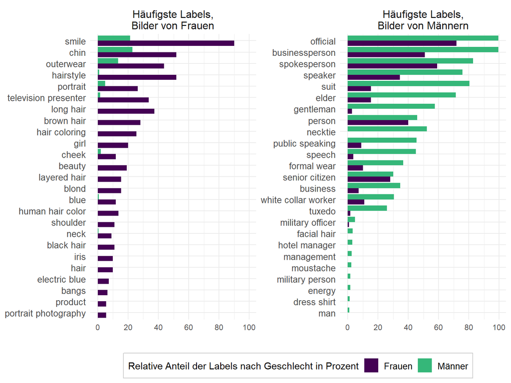

```r
# apply function
gcv_diff <- key_diff(gcv_dfm, groups = "gender", groups1_name = "Female",
         groups2_name = "Male", group1_obs = 110, group2_obs = 430)

# visualize results
gcv_diff_plot <- gcv_diff %>%
  ggplot(aes(x = feature, rel_total, fill = key)) +
  geom_bar(stat = "identity", position = "dodge")  +
  coord_flip() +
  facet_wrap(ifelse(groups == "Male", "Häufigste Labels,\nBilder von Männern",
                    "Häufigste Labels,\nBilder von Frauen") ~ .,
              scales = 'free_y')  +

  scale_x_reordered() +
  scale_y_continuous(labels = scales::label_percent(suffix = ""),
                     breaks = pretty_breaks(n = 5)) +

  scale_fill_manual(
    values = viridis(n = 4)[c(1, 3)],
    name = "Relative Anteil der Labels nach Geschlecht in Prozent",
    labels = c("Frauen", "Männer")
  )  +
  labs(x = '',
       y = '') +
  theme_minimal() +
  theme(
    legend.position = "bottom",
    legend.box.background = element_rect(colour = "grey80"),
    legend.text = element_text(size = 10),
    axis.text.x = element_text(angle = 0),
    axis.text.y = element_text(size = 10),
    strip.text.x = element_text(size = 12),
    axis.title.y = element_blank())

gcv_diff_plot
```

```r
# ggsave(
#  'figures/most_gendered_labels.png',
#  bg="white",
#  gcv_diff_plot,
#  dpi = 300,
#  width = 8,
#  height = 6
# )
```

### 3.3.2 Unbiased GCV Labels

We also identify GCV labels for which the difference in conditional probabilities between women and men is very low, which suggests that they are unbiased with respect to gender.

```r
# group by gender
gcv_grouped <- dfm_group(gcv_dfm, groups = "gender")
# get counts for each label, calculate probabilities
gcv_nodiff <- textstat_keyness(gcv_grouped,  target = "Male", measure = 'chi2') %>%
  mutate(n_all = n_target + n_reference,
         obs_female = 110, obs_male = 430,
         prob_female = n_reference / obs_female,
         prob_male = n_target / obs_male,
         prob_diff = abs(prob_female - prob_male))

gcv_nodiff  <-  gcv_nodiff %>%
  filter(prob_diff < 0.2 & n_target > 10 & n_reference > 10)

gcv_nodiff$feature
```

```
## [1] "white_collar_worker" "person"              "senior_citizen"
## [4] "forehead"
```

## 3.4 Manual coding of image labels

For the remainder of this document, we will focus on analysis of GCV output. To get a better understanding for what kind of labels might be biased, we manually coded all labels returned by GCV for the photographs into a smaller set of categories: ‘physical trait / body’, ‘occpupation’, ‘clothing / apparel’, ‘color / adjective’ and ‘other’.

```r
label_cats <- read_tsv("data/imagelabels_cat_data.tsv")
head(label_cats)
```

```
## # A tibble: 6 x 2
##   label      cat
##   <chr>      <chr>
## 1 actor      occupation
## 2 afro       physicaltrait_body
## 3 bangs      physicaltrait_body
## 4 beard      physicaltrait_body
## 5 beauty     physicaltrait_body
## 6 black_hair physicaltrait_body
```

This code creates category counts for each photograph:

```r
labs <- label_cats %>%
  pull(cat) %>% set_names(label_cats$label)

# function for finding labels and corresponding categories
look_up <- function(labels) {
  parsed <-  labels
  for (x in seq_along(labels)) {
    parsed[[x]] <- labs[[labels[[x]]]]
  }
  return(parsed %>% table() %>% as.data.frame() %>%
           set_names("label", "freq")) %>% spread(label, freq)
}

labels_freqs_list <- str_split(mc_df$wiki_img_labels, ", ") %>% map(look_up)

# New code had to be added because the code from the original study did not work.
# The reason for this is unclear. The logic could be imitated nevertheless.

# extract the unique categories
categories <- unique(unlist(lapply(labels_freqs_list, function(entry) entry$label)))

# creating an empty dataframe with the categories as columns
df <- data.frame(matrix(NA, ncol = length(categories), nrow = length(labels_freqs_list)))
colnames(df) <- categories

# function to update the data frame with the frequencies
update_dataframe <- function(entry) {
  new_row <- rep(NA, length(categories))
  for (i in seq_along(entry$label)) {
    category <- as.character(entry$label[i])
    freq <- entry$freq[i]
    new_row[which(categories == category)] <- freq
  }
  return(new_row)
}

# iteration over the list entries and update of the data frame
for (i in seq_along(labels_freqs_list)) {
  df[i, ] <- update_dataframe(labels_freqs_list[[i]])
}

# recode entries with "na" as 0
df <- df %>% mutate_all(~replace_na(., 0))

head(df)
```

```
##   clothing_apparel color_adjective occupation other physicaltrait_body
## 1                4               1          5     1                  0
## 2                0               0          8     0                  0
## 3                0               0          5     1                  0
## 4                3               1          5     1                  1
## 5                5               1          4     0                  1
## 6                3               1          7     0                  2
```

```r
# merge data frames
mc_df <- bind_cols(mc_df, df)
```

Check distribution of target variables

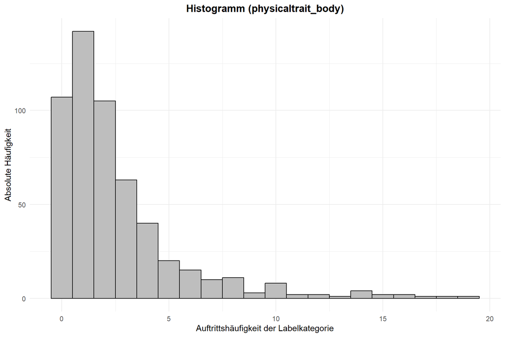

```r
ggplot(mc_df, aes(x = physicaltrait_body)) +
  geom_histogram(binwidth = 1, fill = "grey", color = "black") +
  labs(title = "Histogramm (physicaltrait_body)",
       x = "Auftrittshäufigkeit der Labelkategorie",
       y = "Absolute Häufigkeit") +
  theme_minimal() +
  theme(plot.title = element_text(hjust = 0.5, face = "bold"))
```

```r
ggsave(
 'figures/distribution_physicaltrait_body.png',
 bg="white",
 width = 8,
 height = 6,
 dpi = 300
)
```

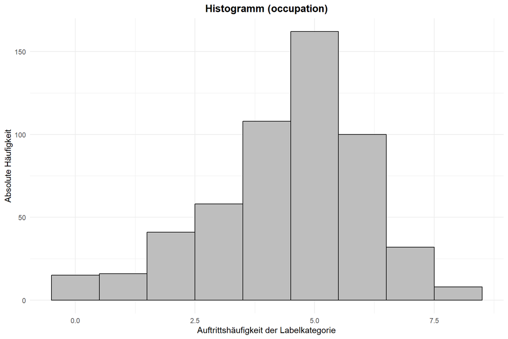

```r
ggplot(mc_df, aes(x = occupation)) +
  geom_histogram(binwidth = 1, fill = "grey", color = "black") +
  labs(title = "Histogramm (occupation)",
       x = "Auftrittshäufigkeit der Labelkategorie",
       y = "Absolute Häufigkeit") +
  theme_minimal() +
  theme(plot.title = element_text(hjust = 0.5, face = "bold"))
```

```r
ggsave(
 'figures/distribution_occupation.png',
 bg="white",
 width = 8,
 height = 6,
 dpi = 300
)
```

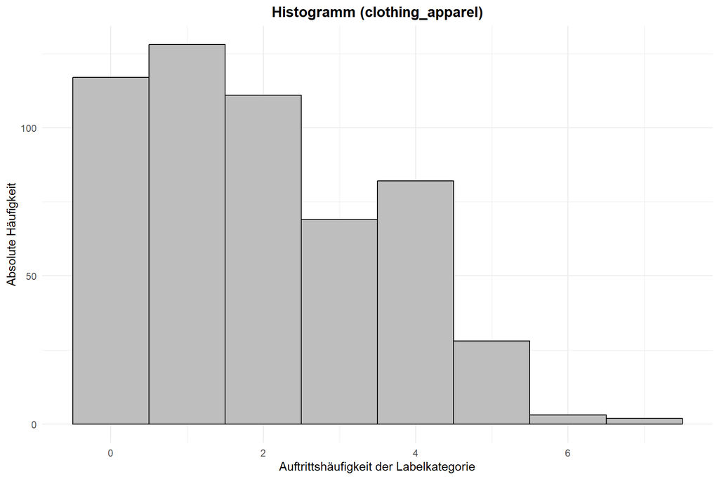

```r
ggplot(mc_df, aes(x = clothing_apparel)) +
  geom_histogram(binwidth = 1, fill = "grey", color = "black") +
  labs(title = "Histogramm (clothing_apparel)",
       x = "Auftrittshäufigkeit der Labelkategorie",
       y = "Absolute Häufigkeit") +
  theme_minimal() +
  theme(plot.title = element_text(hjust = 0.5, face = "bold"))
```

```r
ggsave(
 'figures/distribution_clothing_apparel.png',
 bg="white",
 width = 8,
 height = 6,
 dpi = 300
)
```

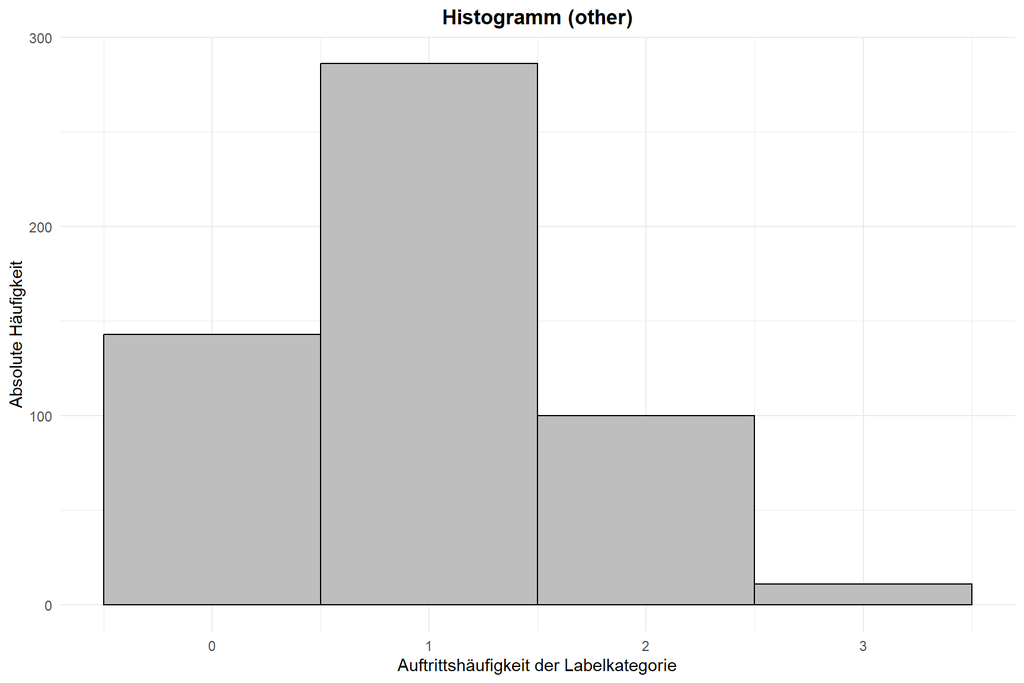

```r
ggplot(mc_df, aes(x = other)) +
  geom_histogram(binwidth = 1, fill = "grey", color = "black") +
  labs(title = "Histogramm (other)",
       x = "Auftrittshäufigkeit der Labelkategorie",
       y = "Absolute Häufigkeit") +
  theme_minimal() +
  theme(plot.title = element_text(hjust = 0.5, face = "bold"))
```

```r
ggsave(
 'figures/distribution_other.png',
 bg="white",
 width = 8,
 height = 6,
 dpi = 300
)
```

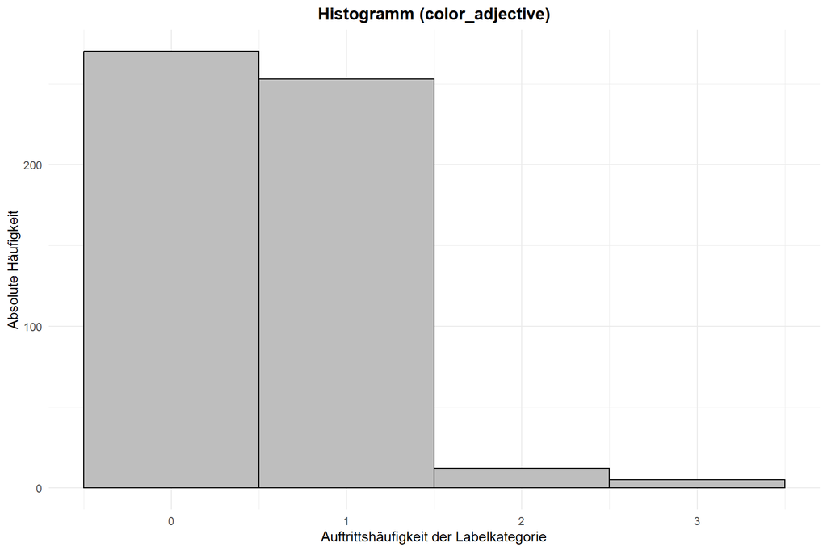

```r
ggplot(mc_df, aes(x = color_adjective)) +
  geom_histogram(binwidth = 1, fill = "grey", color = "black") +
  labs(title = "Histogramm (color_adjective)",
       x = "Auftrittshäufigkeit der Labelkategorie",
       y = "Absolute Häufigkeit") +
  theme_minimal() +
  theme(plot.title = element_text(hjust = 0.5, face = "bold"))
```

```r
ggsave(
 'figures/distribution_color_adjective.png',
 bg="white",
 width = 8,
 height = 6,
 dpi = 300
)
```

## 3.5 Modeling Label Counts

Using poisson & negative binomial regression models, we model category counts and include covariates for age, ethnicity, and party of MCs.

```r
mc_df %>% count(ethnicity, sort = TRUE)
```

```
## # A tibble: 7 x 2
##   ethnicity                   n
##   <chr>                   <int>
## 1 white                     428
## 2 african_american           49
## 3 hispanic                   44
## 4 asian                      15
## 5 indian                      2
## 6 african_american, asian     1
## 7 hispanic, asian             1
```

Due to the skewed distribution we only differentiate between “White” and “Non-White” for ethnicity.

```r
mc_df_reg <- mc_df %>% filter(party != "Independent") %>%
                   mutate(gender = as.factor(gender),
                          party = as.factor(party),
                          eth_white = if_else(ethnicity == "white",
                                              "White", "Non-white") %>% as.factor())
# poisson regressions
apparel <- glm(clothing_apparel ~ gender + eth_white + party + age,
               data = mc_df_reg,
               family = poisson())
physical <-  glm(physicaltrait_body ~ gender + eth_white  + party  + age,
                 data = mc_df_reg,
                 family = poisson())
occupation <- glm(occupation ~ gender + eth_white + party  + age,
                  data = mc_df_reg,
                  family = poisson())
color_adjective <- glm(color_adjective ~ gender + eth_white + party  + age,
                       data = mc_df_reg,
                       family = poisson())
other <- glm(other ~ gender + ethnicity + party  + age,
             data = mc_df_reg,  family = poisson())
```

```r
eth_white_table <- table(mc_df_reg$eth_white)
prop.table(eth_white_table) * 100
```

```
##
## Non-white     White
##  20.81784  79.18216
```

Check choice of poisson distribution

Set seed = 42 to ensure reproducibility

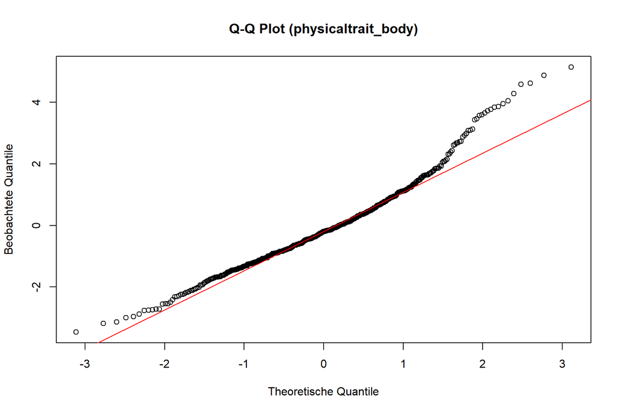

```r
set.seed(42)
qqnorm(qresid(physical),
       main = "Q-Q Plot (physicaltrait_body)",
       xlab = "Theoretische Quantile",
       ylab = "Beobachtete Quantile");
qqline(qresid(physical), col="red")
```

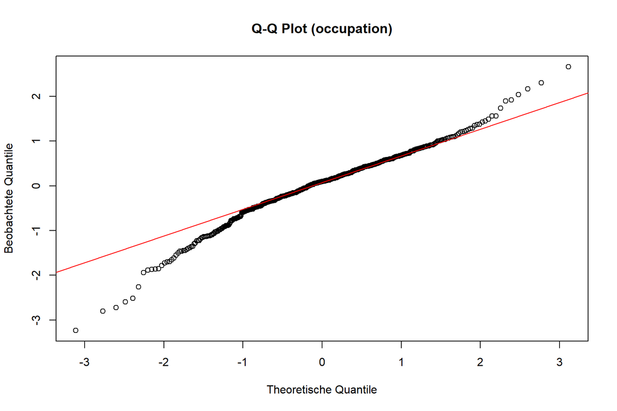

```r
set.seed(42)
qqnorm(qresid(occupation),
       main = "Q-Q Plot (occupation)",
       xlab = "Theoretische Quantile",
       ylab = "Beobachtete Quantile");
qqline(qresid(occupation), col="red")
```

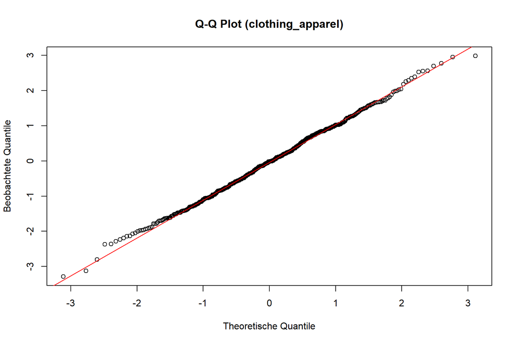

```r
set.seed(42)
qqnorm(qresid(apparel),
       main = "Q-Q Plot (clothing_apparel)",
       xlab = "Theoretische Quantile",
       ylab = "Beobachtete Quantile");
qqline(qresid(apparel), col="red")
```

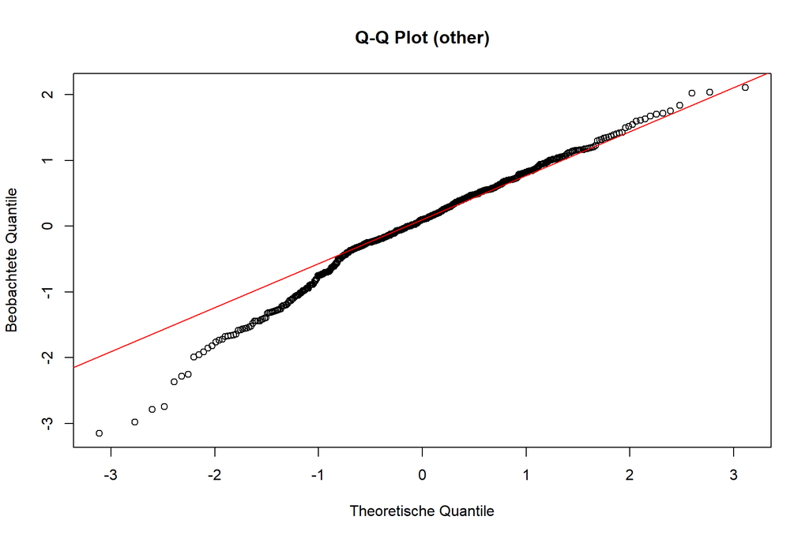

```r
set.seed(42)
qqnorm(qresid(other),
       main = "Q-Q Plot (other)",
       xlab = "Theoretische Quantile",
       ylab = "Beobachtete Quantile");
qqline(qresid(other), col="red")
```

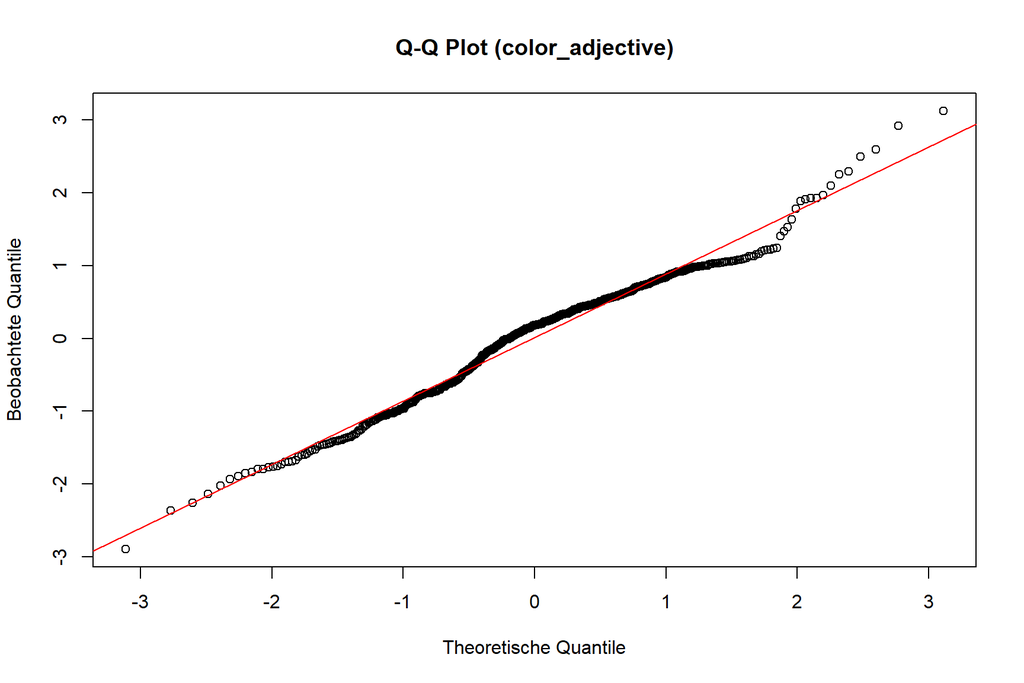

```r
set.seed(42)
qqnorm(qresid(color_adjective),
       main = "Q-Q Plot (color_adjective)",
       xlab = "Theoretische Quantile",
       ylab = "Beobachtete Quantile");
qqline(qresid(color_adjective), col="red")
```

Get overview of poisson regression models

```r
summary(apparel)
```

```
##
## Call:
## glm(formula = clothing_apparel ~ gender + eth_white + party +
##     age, family = poisson(), data = mc_df_reg)
##
## Deviance Residuals:
##     Min       1Q   Median       3Q      Max
## -2.8031  -1.0229  -0.1529   0.6470   3.0840
##
## Coefficients:
##                  Estimate Std. Error z value Pr(>|z|)
## (Intercept)      1.473181   0.197375   7.464 8.40e-14 ***
## genderMale       0.582021   0.099289   5.862 4.58e-09 ***
## eth_whiteWhite   0.198279   0.089114   2.225   0.0261 *
## partyRepublican  0.002573   0.069569   0.037   0.9705
## age             -0.024659   0.002928  -8.421  < 2e-16 ***
## ---
## Signif. codes:  0 '***' 0.001 '**' 0.01 '*' 0.05 '.' 0.1 ' ' 1
##
## (Dispersion parameter for poisson family taken to be 1)
##
##     Null deviance: 813.97  on 537  degrees of freedom
## Residual deviance: 679.05  on 533  degrees of freedom
## AIC: 1825.4
##
## Number of Fisher Scoring iterations: 5
```

```r
summary(physical)
```

```
##
## Call:
## glm(formula = physicaltrait_body ~ gender + eth_white + party +
##     age, family = poisson(), data = mc_df_reg)
##
## Deviance Residuals:
##     Min       1Q   Median       3Q      Max
## -3.6737  -1.1870  -0.4621   0.5783   5.1754
##
## Coefficients:
##                  Estimate Std. Error z value Pr(>|z|)
## (Intercept)      0.968809   0.171513   5.649 1.62e-08 ***
## genderMale      -1.084657   0.058737 -18.466  < 2e-16 ***
## eth_whiteWhite   0.334401   0.071518   4.676 2.93e-06 ***
## partyRepublican -0.132167   0.061970  -2.133 0.032944 *
## age              0.008536   0.002556   3.340 0.000838 ***
## ---
## Signif. codes:  0 '***' 0.001 '**' 0.01 '*' 0.05 '.' 0.1 ' ' 1
##
## (Dispersion parameter for poisson family taken to be 1)
##
##     Null deviance: 1541.5  on 537  degrees of freedom
## Residual deviance: 1135.1  on 533  degrees of freedom
## AIC: 2340.2
##
## Number of Fisher Scoring iterations: 5
```

```r
summary(occupation)
```

```
##
## Call:
## glm(formula = occupation ~ gender + eth_white + party + age,
##     family = poisson(), data = mc_df_reg)
##
## Deviance Residuals:
##      Min        1Q    Median        3Q       Max
## -2.95634  -0.42570   0.01557   0.41819   2.42204
##
## Coefficients:
##                  Estimate Std. Error z value Pr(>|z|)
## (Intercept)      1.673351   0.131180  12.756  < 2e-16 ***
## genderMale       0.464201   0.062118   7.473 7.85e-14 ***
## eth_whiteWhite  -0.002527   0.056886  -0.044    0.965
## partyRepublican  0.037221   0.046567   0.799    0.424
## age             -0.009824   0.001933  -5.082 3.73e-07 ***
## ---
## Signif. codes:  0 '***' 0.001 '**' 0.01 '*' 0.05 '.' 0.1 ' ' 1
##
## (Dispersion parameter for poisson family taken to be 1)
##
##     Null deviance: 419.06  on 537  degrees of freedom
## Residual deviance: 311.49  on 533  degrees of freedom
## AIC: 2063.1
##
## Number of Fisher Scoring iterations: 5
```

```r
summary(color_adjective)
```

```
##
## Call:
## glm(formula = color_adjective ~ gender + eth_white + party +
##     age, family = poisson(), data = mc_df_reg)
##
## Deviance Residuals:
##     Min       1Q   Median       3Q      Max
## -1.1457  -1.0959  -0.1678   0.4612   2.9458
##
## Coefficients:
##                   Estimate Std. Error z value Pr(>|z|)
## (Intercept)     -1.2004441  0.3912612  -3.068  0.00215 **
## genderMale       0.4908742  0.1805181   2.719  0.00654 **
## eth_whiteWhite   0.3269368  0.1767220   1.850  0.06431 .
## partyRepublican -0.0610528  0.1312527  -0.465  0.64182
## age             -0.0009621  0.0055777  -0.172  0.86305
## ---
## Signif. codes:  0 '***' 0.001 '**' 0.01 '*' 0.05 '.' 0.1 ' ' 1
##
## (Dispersion parameter for poisson family taken to be 1)
##
##     Null deviance: 423.89  on 537  degrees of freedom
## Residual deviance: 409.37  on 533  degrees of freedom
## AIC: 969.69
##
## Number of Fisher Scoring iterations: 6
```

```r
summary(other)
```

```
##
## Call:
## glm(formula = other ~ gender + ethnicity + party + age, family = poisson(),
##     data = mc_df_reg)
##
## Deviance Residuals:
##      Min        1Q    Median        3Q       Max
## -1.51025  -1.23124   0.00707   0.17372   1.88028
##
## Coefficients:
##                                   Estimate Std. Error z value Pr(>|z|)
## (Intercept)                      -0.602807   0.329596  -1.829   0.0674 .
## genderMale                        0.149020   0.122557   1.216   0.2240
## ethnicityafrican_american, asian  0.325834   1.016233   0.321   0.7485
## ethnicityasian                    0.044288   0.332695   0.133   0.8941
## ethnicityhispanic                 0.148344   0.224243   0.662   0.5083
## ethnicityhispanic, asian          0.823799   0.725731   1.135   0.2563
## ethnicityindian                   0.532059   0.605869   0.878   0.3798
## ethnicitywhite                    0.111829   0.174485   0.641   0.5216
## partyRepublican                   0.042515   0.101102   0.421   0.6741
## age                               0.005129   0.004236   1.211   0.2260
## ---
## Signif. codes:  0 '***' 0.001 '**' 0.01 '*' 0.05 '.' 0.1 ' ' 1
##
## (Dispersion parameter for poisson family taken to be 1)
##
##     Null deviance: 388.16  on 537  degrees of freedom
## Residual deviance: 382.40  on 528  degrees of freedom
## AIC: 1266.1
##
## Number of Fisher Scoring iterations: 5
```

```r
# dispersion tests
dispersiontest(apparel, trafo = 1)
```

```
##
##  Overdispersion test
##
## data:  apparel
## z = 2.0246, p-value = 0.02146
## alternative hypothesis: true alpha is greater than 0
## sample estimates:
##    alpha
## 0.132935
```

```r
dispersiontest(physical, trafo = 1)
```

```
##
##  Overdispersion test
##
## data:  physical
## z = 5.829, p-value = 2.789e-09
## alternative hypothesis: true alpha is greater than 0
## sample estimates:
##    alpha
## 1.265828
```

```r
dispersiontest(occupation, trafo = 1)
```

```
##
##  Overdispersion test
##
## data:  occupation
## z = -12.277, p-value = 1
## alternative hypothesis: true alpha is greater than 0
## sample estimates:
##      alpha
## -0.4980232
```

```r
dispersiontest(color_adjective, trafo = 1)
```

```
##
##  Overdispersion test
##
## data:  color_adjective
## z = -4.5435, p-value = 1
## alternative hypothesis: true alpha is greater than 0
## sample estimates:
##      alpha
## -0.2874472
```

```r
dispersiontest(other, trafo = 1)
```

```
##
##  Overdispersion test
##
## data:  other
## z = -11.551, p-value = 1
## alternative hypothesis: true alpha is greater than 0
## sample estimates:
##      alpha
## -0.4511799
```

```r
# run negative binomials instead of poisson due to partial overdisperson
apparel <- glm.nb(clothing_apparel ~ gender + eth_white + party  + age,
                  data = mc_df_reg)

physical <- glm.nb(physicaltrait_body ~ gender + eth_white + party  + age,
                   data = mc_df_reg)
occupation <- glm.nb(occupation ~ gender + eth_white + party  + age,
                     data = mc_df_reg)
color_adjective <- glm.nb(color_adjective ~ gender + eth_white + party  + age,
                          data = mc_df_reg)
other <- glm.nb(other ~ gender + eth_white + party  + age,
                data = mc_df_reg)
```

Get overview of negative binomial regression models

```r
summary(apparel)
```

```
##
## Call:
## glm.nb(formula = clothing_apparel ~ gender + eth_white + party +
##     age, data = mc_df_reg, init.theta = 59.33334488, link = log)
##
## Deviance Residuals:
##     Min       1Q   Median       3Q      Max
## -2.7613  -1.0076  -0.1504   0.6355   3.0123
##
## Coefficients:
##                  Estimate Std. Error z value Pr(>|z|)
## (Intercept)      1.478509   0.200811   7.363 1.80e-13 ***
## genderMale       0.580474   0.100395   5.782 7.39e-09 ***
## eth_whiteWhite   0.198721   0.090620   2.193   0.0283 *
## partyRepublican  0.003573   0.070854   0.050   0.9598
## age             -0.024743   0.002983  -8.293  < 2e-16 ***
## ---
## Signif. codes:  0 '***' 0.001 '**' 0.01 '*' 0.05 '.' 0.1 ' ' 1
##
## (Dispersion parameter for Negative Binomial(59.3333) family taken to be 1)
##
##     Null deviance: 792.29  on 537  degrees of freedom
## Residual deviance: 661.41  on 533  degrees of freedom
## AIC: 1827.2
##
## Number of Fisher Scoring iterations: 1
##
##
##               Theta:  59
##           Std. Err.:  123
##
##  2 x log-likelihood:  -1815.203
```

```r
summary(physical)
```

```
##
## Call:
## glm.nb(formula = physicaltrait_body ~ gender + eth_white + party +
##     age, data = mc_df_reg, init.theta = 2.334846248, link = log)
##
## Deviance Residuals:
##     Min       1Q   Median       3Q      Max
## -2.5327  -0.7803  -0.3512   0.4137   3.2088
##
## Coefficients:
##                  Estimate Std. Error z value Pr(>|z|)
## (Intercept)      0.800146   0.255529   3.131  0.00174 **
## genderMale      -1.086488   0.094916 -11.447  < 2e-16 ***
## eth_whiteWhite   0.275687   0.108980   2.530  0.01142 *
## partyRepublican -0.126946   0.091888  -1.382  0.16712
## age              0.012026   0.003821   3.147  0.00165 **
## ---
## Signif. codes:  0 '***' 0.001 '**' 0.01 '*' 0.05 '.' 0.1 ' ' 1
##
## (Dispersion parameter for Negative Binomial(2.3348) family taken to be 1)
##
##     Null deviance: 758.87  on 537  degrees of freedom
## Residual deviance: 578.07  on 533  degrees of freedom
## AIC: 2127.9
##
## Number of Fisher Scoring iterations: 1
##
##
##               Theta:  2.335
##           Std. Err.:  0.292
##
##  2 x log-likelihood:  -2115.855
```

```r
summary(occupation)
```

```
##
## Call:
## glm.nb(formula = occupation ~ gender + eth_white + party + age,
##     data = mc_df_reg, init.theta = 138683.8387, link = log)
##
## Deviance Residuals:
##      Min        1Q    Median        3Q       Max
## -2.95632  -0.42569   0.01557   0.41818   2.42200
##
## Coefficients:
##                  Estimate Std. Error z value Pr(>|z|)
## (Intercept)      1.673353   0.131182  12.756  < 2e-16 ***
## genderMale       0.464201   0.062119   7.473 7.85e-14 ***
## eth_whiteWhite  -0.002526   0.056887  -0.044    0.965
## partyRepublican  0.037221   0.046568   0.799    0.424
## age             -0.009824   0.001933  -5.082 3.73e-07 ***
## ---
## Signif. codes:  0 '***' 0.001 '**' 0.01 '*' 0.05 '.' 0.1 ' ' 1
##
## (Dispersion parameter for Negative Binomial(138683.8) family taken to be 1)
##
##     Null deviance: 419.05  on 537  degrees of freedom
## Residual deviance: 311.48  on 533  degrees of freedom
## AIC: 2065.1
##
## Number of Fisher Scoring iterations: 1
##
##
##               Theta:  138684
##           Std. Err.:  765158
## Warning while fitting theta: iteration limit reached
##
##  2 x log-likelihood:  -2053.086
```

```r
summary(color_adjective)
```

```
##
## Call:
## glm.nb(formula = color_adjective ~ gender + eth_white + party +
##     age, data = mc_df_reg, init.theta = 11750.16598, link = log)
##
## Deviance Residuals:
##     Min       1Q   Median       3Q      Max
## -1.1457  -1.0958  -0.1678   0.4611   2.9457
##
## Coefficients:
##                   Estimate Std. Error z value Pr(>|z|)
## (Intercept)     -1.2004441  0.3912698  -3.068  0.00215 **
## genderMale       0.4908739  0.1805212   2.719  0.00654 **
## eth_whiteWhite   0.3269374  0.1767254   1.850  0.06432 .
## partyRepublican -0.0610518  0.1312560  -0.465  0.64183
## age             -0.0009621  0.0055779  -0.172  0.86305
## ---
## Signif. codes:  0 '***' 0.001 '**' 0.01 '*' 0.05 '.' 0.1 ' ' 1
##
## (Dispersion parameter for Negative Binomial(11750.17) family taken to be 1)
##
##     Null deviance: 423.87  on 537  degrees of freedom
## Residual deviance: 409.36  on 533  degrees of freedom
## AIC: 971.7
##
## Number of Fisher Scoring iterations: 1
##
##
##               Theta:  11750
##           Std. Err.:  65990
## Warning while fitting theta: iteration limit reached
##
##  2 x log-likelihood:  -959.704
```

```r
summary(other)
```

```
##
## Call:
## glm.nb(formula = other ~ gender + eth_white + party + age, data = mc_df_reg,
##     init.theta = 30613.57121, link = log)
##
## Deviance Residuals:
##      Min        1Q    Median        3Q       Max
## -1.50781  -1.26336   0.00047   0.17099   1.89623
##
## Coefficients:
##                  Estimate Std. Error z value Pr(>|z|)
## (Intercept)     -0.498207   0.284638  -1.750   0.0801 .
## genderMale       0.161230   0.120814   1.335   0.1820
## eth_whiteWhite   0.012483   0.122216   0.102   0.9186
## partyRepublican  0.052427   0.100487   0.522   0.6019
## age              0.004765   0.004162   1.145   0.2522
## ---
## Signif. codes:  0 '***' 0.001 '**' 0.01 '*' 0.05 '.' 0.1 ' ' 1
##
## (Dispersion parameter for Negative Binomial(30613.57) family taken to be 1)
##
##     Null deviance: 388.15  on 537  degrees of freedom
## Residual deviance: 384.27  on 533  degrees of freedom
## AIC: 1260
##
## Number of Fisher Scoring iterations: 1
##
##
##               Theta:  30614
##           Std. Err.:  189616
## Warning while fitting theta: iteration limit reached
##
##  2 x log-likelihood:  -1247.957
```

Now we combine all estimates and visualize effect estimates for different covariates, while holding other respective covariates at their observed values.

```r
pred_apparel <- ggeffect(apparel)
pred_apparel$age <- pred_apparel$age %>% mutate(x = as.character(x))
pred_apparel <- pred_apparel %>% plyr::ldply(., data.frame) %>%
  mutate(cat = "clothing / apparel")

pred_physical <- ggeffect(physical)
pred_physical$age <- pred_physical$age %>% mutate(x = as.character(x))
pred_physical <- pred_physical %>% plyr::ldply(., data.frame) %>%
  mutate(cat = "physical trait / body")


pred_occupation <- ggeffect(occupation)
pred_occupation$age <- pred_occupation$age %>% mutate(x = as.character(x))
pred_occupation <- pred_occupation %>% plyr::ldply(., data.frame) %>%
  mutate(cat = "occupation")


pred_color <- ggeffect(color_adjective)
pred_color$age <- pred_color$age %>% mutate(x = as.character(x))
pred_color <- pred_color %>% plyr::ldply(., data.frame) %>%
  mutate(cat = "color / adjective")


pred_other <- ggeffect(other)
pred_other$age <- pred_other$age %>% mutate(x = as.character(x))
pred_other <- pred_other %>% plyr::ldply(., data.frame) %>%
  mutate(cat = "other")

all_preds = list(pred_apparel,
                 pred_physical,
                 pred_occupation,
                 pred_color,
                 pred_other) %>%
  plyr::ldply(., data.frame) %>%
  rename(label = x, indicator = group)
```

The following code creates the average predicted category counts conditional on gender:

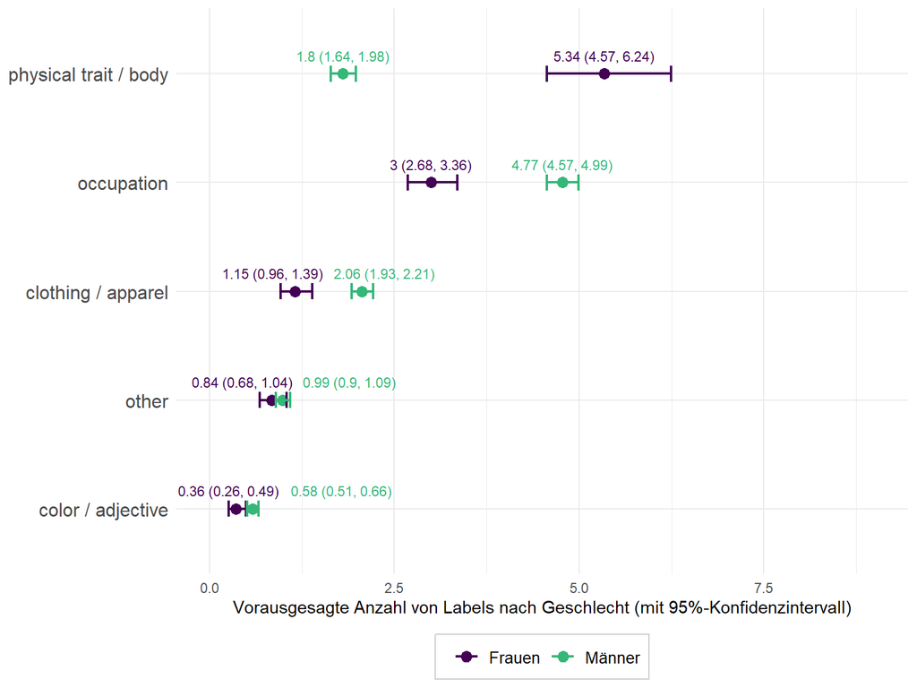

```r
# individual lateral spacing for each category
nudge_values <- c(c(-0.3, 0.3), c(0, 0), c(0, 0), c(-0.1, 1.2), c(-0.4, 0.9))

all_preds %>%
  filter(indicator == "gender") %>%
  ggplot(aes(
    x = predicted,
    y =  reorder(cat, predicted),
    color = label,
    group = 1
  )) +
  geom_point(size = 3) +
  scale_color_manual(values = viridis(n = 4)[c(1, 3)],
                     name = NULL,
                     labels = c("Frauen", "Männer"))  +
  scale_x_continuous(limits = c(0, 9)) +
  geom_errorbarh(aes(
    xmin = conf.low,
    xmax = conf.high,
    height = 0.15
  ), size = 0.75) +
geom_text(aes(label = paste(round(predicted, 2), " ", "(", round(conf.low, 2) , ", ", round(conf.high, 2), ")", sep = "")),
            vjust = -1.2, size = 3, position = position_nudge(x = nudge_values)) +
  #  scale_shape_manual(values=c(19, 15))+
  scale_y_discrete(
    limits = c(
      "color / adjective",
      "other",
      "clothing / apparel",
      "occupation",
      "physical trait / body"
    )
  ) +
  labs(x = "Vorausgesagte Anzahl von Labels nach Geschlecht (mit 95%-Konfidenzintervall)",
       y = "label category",
       color = "gender") +
  theme_minimal() +
  theme(
    legend.position = "bottom",
    legend.box.background = element_rect(colour = "grey80"),
    legend.text = element_text(size = 10),
    axis.text.x = element_text(angle = 0),
    axis.text.y = element_text(size = 12),
    strip.text.x = element_text(size = 12),
    axis.title.y = element_blank(),
    plot.title = element_text(size = 14, face = "bold", hjust = 0.5),
    plot.caption = element_text(size = 9, face = "italic")
  )
```

```r
ggsave(
 'figures/predicted_category_counts.png',
 bg="white",
 dpi = 300,
 width = 8,
 height = 6
)
```

## 3.6 Biases in Image Labels of Tweets by MCs

Now, we turn to our dataset of images within tweets posted by MCs. We start with the subset for which we validated image labels with crowdworkers. In the crowd validation dataset each row represents the validation of one particular image label. Note that we only consider labels (and recognized objects) with GCV confidence scores of at least .75.

```r
crowd_df <- read_tsv("data/crowdvalidation_data.tsv")
head(crowd_df)
```

```
## # A tibble: 6 x 13
##   resp_id label_response_number image_number labelresponse   men women children
##     <dbl>                 <dbl>        <dbl>         <dbl> <dbl> <dbl>    <dbl>
## 1     364                     1            1             0     1     0        0
## 2     364                     2            1             0     1     0        0
## 3     364                     3            1             0     1     0        0
## 4     364                     4            1             0     1     0        0
## 5     364                     5            1             0     1     0        0
## 6     364                     6            1             1     1     0        0
## # i 6 more variables: none <dbl>, label <chr>, media_url <chr>,
## #   confidence <dbl>, real_label <dbl>, correct <dbl>
```

### 3.6.1 GCV confidence versus respondent’s checking the box

We examine to what extent GCV’s confidence scores are in line with human judgment about whether image labels are correct.

```r
# vector of tresholds from .75 confidence to .1 confidence
conf_ths <- seq(0.75, 1, 0.02)

# function for treshold lookup
check_treshold <- function(th, data) {
  data <- data %>% filter(!is.na(confidence) & confidence >= th)
  share_corr <- sum(data$labelresponse) / nrow(data)
  return (tibble(
    treshold = th,
    correct = share_corr,
    obs = nrow(data)
  ))

}

#apply functions
conf_dfs <- tibble()
for (th in seq_along(conf_ths)) {
  conf_dfs <- bind_rows(conf_dfs, check_treshold(conf_ths[th], crowd_df))
}
```

The following graph visualizes the results:

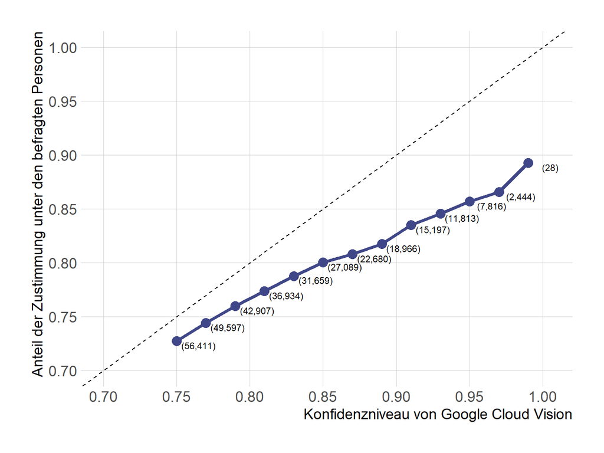

```r
conf_dfs %>% ggplot(aes(treshold, correct))  +
  geom_point(size = 4, color = '#404788FF') +
  geom_line(color = '#404788FF', size = 1.5) +
  scale_x_continuous(breaks = pretty_breaks(n = 7),
                     limits = c(0.70, NA)) +

  scale_y_continuous(breaks = pretty_breaks(n = 7),
                     limits = c(0.70, 1.0)) +
  geom_abline(intercept = 0,
              slope = 1,
              linetype = 2) +
  geom_text(
    aes(label = paste0('(', comma(obs), ')')),
    nudge_x = 0.015,
    nudge_y = -0.004,
    size = 3
  ) +
  labs(x = "Konfidenzniveau von Google Cloud Vision",
       y = "Anteil der Zustimmung unter den befragten Personen")
```

```r
# ggsave(
#  'figures/confidence_human_agreement.png',
#  bg="white",
#  width = 8,
#  height = 6,
#  dpi = 300
# )
```

# 4 Replication

## 4.1 Data collection

Data collection via Google Cloud Vision API  
Using an API key for Google Cloud Vision, the politician images can be passed to GCV’s interface for processing. In response, we receive a dataset with labels for all 540 images.

```r
# Preparations to use Google Cloud Vision API
# store & hide GCV API key in .Renviron file
#usethis::edit_r_environ()
```

```r
# API key set as environment variable
Sys.setenv(gvision_key = Sys.getenv('GCV_key'))
```

```r
# initialization function
gvision_init()
```

```
## Succesfully initialized authentification credentials.
```

```r
# get list of paths to the images
filenames_women <- list.files(path = "mc_images_split/mc_women",
                        pattern="*.jpg",
                        full.names = TRUE)
head(filenames_women)
```

```
## [1] "mc_images_split/mc_women/Alma_Adams.jpg"
## [2] "mc_images_split/mc_women/Amata_Coleman_Radewagen.jpg"
## [3] "mc_images_split/mc_women/Amy_Klobuchar.jpg"
## [4] "mc_images_split/mc_women/Ann_McLane_Kuster.jpg"
## [5] "mc_images_split/mc_women/Ann_Wagner.jpg"
## [6] "mc_images_split/mc_women/Anna_Eshoo.jpg"
```

```r
# get list of paths to the images
filenames_men <- list.files(path = "mc_images_split/mc_men",
                        pattern="*.jpg",
                        full.names = TRUE)
head(filenames_men)
```

```
## [1] "mc_images_split/mc_men/Adam_Kinzinger.jpg"
## [2] "mc_images_split/mc_men/Adam_Schiff.jpg"
## [3] "mc_images_split/mc_men/Adam_Smith_(politician).jpg"
## [4] "mc_images_split/mc_men/Adrian_Smith_(politician).jpg"
## [5] "mc_images_split/mc_men/Adriano_Espaillat.jpg"
## [6] "mc_images_split/mc_men/Al_Franken.jpg"
```

```r
# get image annotations
# Send post request to GCV-API
results_women <- get_annotations(images = filenames_women,  # image character vector
                           features = 'label',              # request all available features
                           max_res = 25,                    # maximum number of results per feature
                           mode = 'local')                  # determine image type

img_data_women <- parse_annotations(results_women)          # returns list of data frames
names(img_data_women)                                       # all available features

results_men <- get_annotations(images = filenames_men,      # image character vector
                           features = 'label',              # request all available features
                           max_res = 25,                    # maximum number of results per feature
                           mode = 'local')                  # determine image type

img_data_men <- parse_annotations(results_men)              # returns list of data frames
names(img_data_men)                                         # all available features
```

```r
# get all labels
img_labels_women <- img_data_women$labels
head(img_labels_women)

img_labels_men <- img_data_men$labels
head(img_labels_men)
```

```r
# save data
write.csv(img_labels_women,
          file = "data_replication/imgrec_women_23.csv",
          row.names = F)
```

```r
# save data
write.csv(img_labels_men,
          file = "data_replication/imgrec_men_23.csv",
          row.names = F)
```

## 4.2 Data preparation

```r
# import collected data for more detailed analysis
df_women <- read.csv('data_replication/imgrec_women_23.csv', encoding='utf-8')
df_men   <- read.csv('data_replication/imgrec_men_23.csv', encoding='utf-8')
```

```r
# bring replication labels in same format as original
df_women <- df_women %>%
  mutate(description = gsub("\\s", "_", description))

df_men <- df_men %>%
  mutate(description = gsub("\\s", "_", description))
```

```r
df_total <- full_join(df_women, df_men)
dim(df_total)
```

```
## [1] 12380     5
```

```r
# Number of labels for each person/image
12380/540
```

```
## [1] 22.92593
```

```r
# get unique labels for manual coding of categories
unique_labels <- unique(df_total$description)
summary(unique_labels)
```

```
##    Length     Class      Mode
##       210 character character
```

```r
str(unique_labels)
```

```
##  chr [1:210] "Glasses" "Smile" "Flag_of_the_united_states" "Sleeve" ...
```

```r
# prepare csv-format of unique labels for manual coding
df_unique_labels <- data.frame(labels = unique_labels)
write.csv(df_unique_labels,
          file = "data_replication/labels_manual_coding.csv",
          row.names = FALSE)
```

```r
df_total_desc <- aggregate(description ~ img_id, data = df_total, FUN = c)
df_total_score <- aggregate(score ~ img_id, data = df_total, FUN = c)

df_total <- merge(df_total_desc, df_total_score, by = "img_id", all = TRUE)
dim(df_total)
```

```
## [1] 540   3
```

```r
# recode description and score
df_total$description <- sapply(df_total$description, paste, collapse = ", ")
df_total$score<- sapply(df_total$score, paste, collapse = ", ")
```

```r
# regular expression to get clean wikipedia id
df_total <- df_total %>%
  mutate(wikipedia_id = str_remove(str_extract(img_id, "(?<=/)[^/]+$"), "\\.jpg$"))
```

```r
# merge original and replication data
# select only relevant columns
mc_df_selected <- mc_df[, c("wikipedia_id",
                            "wiki_img_url",
                            "name", "age",
                            "gender",
                            "ethnicity",
                            "type",
                            "party",
                            "state",
                            "wiki_img_labels",
                            "wiki_img_labelsconf",
                            "clothing_apparel",
                            "color_adjective",
                            "occupation",
                            "other",
                            "physicaltrait_body")]

df_total_selected <- df_total[, c("description",
                                  "score",
                                  "wikipedia_id")]

merged_df <- merge(mc_df_selected, df_total_selected, by = "wikipedia_id")

# rename variables oriented to the original
merged_df <- merged_df %>% rename(wiki_img_labels_repl = description, wiki_img_labelsconf_repl = score)

dim(merged_df)
```

```
## [1] 540  18
```

## 4.3 Annotation examples

### 4.3.1 GCV Example

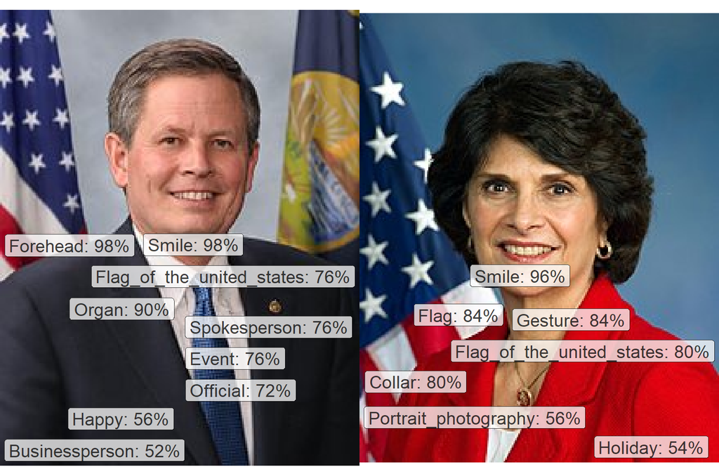

```r
# filtering and reshaping data
img_example1 <-
  merged_df %>% filter(str_detect(wiki_img_url, 'Steve_Daines|Lucille_Roybal')) %>%
  mutate(label = str_split(wiki_img_labels_repl, ', '),
         score = str_split(wiki_img_labelsconf_repl, ', ')) %>%
  unnest(c(label, score)) %>%
  mutate(score = round(as.numeric(score), 2)) %>%
  group_by(name) %>%
  mutate(pixel = score * 200) %>% # for visulization purposes
  dplyr::select(name, gender, party, label, score, pixel, wiki_img_url)

# creating plot
daines <-
  image_read('mc_images/Steve_Daines.jpg') %>%
  image_ggplot() +

  geom_label_repel(
    data = img_example1 %>% filter(name == 'Steve Daines'),
    aes(
      y = pixel - 90 ,
      x =  110,
      label = str_c(label, ': ', percent(score, accuracy = 2))
    ),
    direction = 'both',
    force = 20,
    segment.alpha = 0.00,
    size = 5,
    alpha = 0.75,
    seed = 2
  ) + guides(size = FALSE)


# creating plot
allard <- image_read('mc_images/Lucille_Roybal-Allard.jpg') %>%
  image_ggplot() +

  geom_label_repel(
    data = img_example1 %>% filter(name == 'Lucille Roybal-Allard'),
    aes(
      y = pixel - 90 ,
      x =  90,
      label = str_c(label, ': ', percent(score,  accuracy = 2))
    ),
    direction = 'both',
    force = 5,
    segment.alpha = 0.00,
    size = 5,
    alpha = 0.75,
    seed = 1337
  ) + guides(size = FALSE)

# combining plots
comb1 <- cowplot::plot_grid(daines, allard, labels = NULL)
comb1
```

```r
# ggsave(
#  'figures/example_annotations_repl.png',
#  comb1,
#  dpi = 300,
#  width = 8,
#  height = 5.3
# )
```

## 4.4 Image labels - key differences

Next, we quantify key differences in labels by gender for each image recognition service. We only consider labels that were assigned at least 5 times across all images.

```r
gcv_dfm <- corpus(merged_df,
                  text_field = 'wiki_img_labels_repl',
                  docid_field = 'wikipedia_id') %>%
  dfm(remove_punct = TRUE) %>%
  dfm_trim(min_termfreq = 5)

dim(gcv_dfm)
```

```
## [1] 540 128
```

We create a function to examine group differences based on Chi² tests.

```r
key_diff <- function(featmat, groups,
                     groups1_name,
                     groups2_name,
                     group1_obs, group2_obs) {
  # grouping
  img_grouped <- dfm_group(featmat, groups = groups)


  # compute key labels for group 1
  key1 <- textstat_keyness(img_grouped,  target = groups1_name, measure = 'chi2')
  group_key1 <-
  key1 %>% mutate(
    groups = if_else(chi2 >= 0, groups1_name, groups2_name),
    key = groups1_name,
    chi2_abs = abs(chi2),
    obs_total = group1_obs
  ) %>%
  group_by(groups) %>% top_n(n = 25, wt = chi2_abs) %>% ungroup()

  # compute key labels for group 2
  key2 <- textstat_keyness(img_grouped,  target = groups2_name, measure = 'chi2')
  group_key2 <-
  key2 %>% mutate(
    groups = if_else(chi2 >= 0, groups2_name, groups1_name),
    key = groups2_name,
    chi2_abs = abs(chi2),
    obs_total = group2_obs
  ) %>%
  group_by(groups) %>% top_n(n = 25, wt = chi2_abs) %>% ungroup()


  # combine data and add frequency indicators
comb_key <- group_key1 %>% bind_rows(group_key2) %>%
  mutate(sum_feat = n_target + n_reference,
    rel_feat =  n_target / sum_feat,
    rel_total =  n_target / obs_total,
    feature = str_replace_all(feature, '_', ' ') %>%
              str_trim() %>%
              reorder_within(sum_feat, groups))

return(comb_key)

}
```

### 4.4.1 GCV

25 most gendered labels:

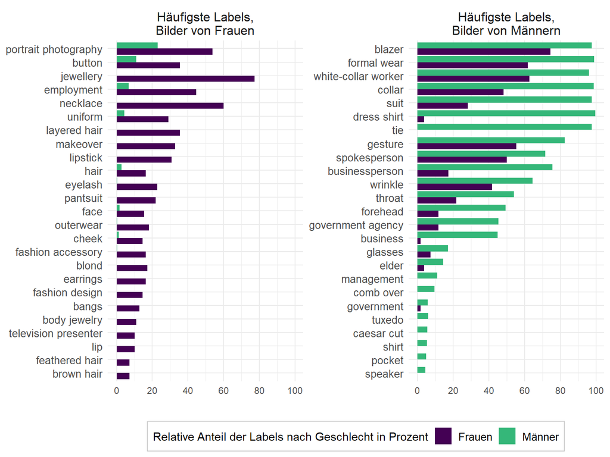

```r
# apply function
gcv_diff <- key_diff(gcv_dfm, groups = "gender", groups1_name = "Female",
         groups2_name = "Male", group1_obs = 110, group2_obs = 430)

# visualize results
gcv_diff_plot <- gcv_diff %>%
  ggplot(aes(x = feature, rel_total, fill = key)) +
  geom_bar(stat = "identity", position = "dodge")  +
  coord_flip() +
  facet_wrap(ifelse(groups == "Male", "Häufigste Labels,\nBilder von Männern",
                    "Häufigste Labels,\nBilder von Frauen") ~ .,
              scales = 'free_y')  +

  scale_x_reordered() +
  scale_y_continuous(labels = scales::label_percent(suffix = ""),
                     breaks = pretty_breaks(n = 5)) +

  scale_fill_manual(
    values = viridis(n = 4)[c(1, 3)],
    name = "Relative Anteil der Labels nach Geschlecht in Prozent",
    labels = c("Frauen", "Männer")
  )  +
  labs(x = '',
       y = '') +
  theme_minimal() +
  theme(
    legend.position = "bottom",
    legend.box.background = element_rect(colour = "grey80"),
    legend.text = element_text(size = 10),
    axis.text.x = element_text(angle = 0),
    axis.text.y = element_text(size = 10),
    strip.text.x = element_text(size = 12),
    axis.title.y = element_blank())

gcv_diff_plot
```

```r
# ggsave(
#  'figures/most_gendered_labels_repl.png',
#  gcv_diff_plot,
#  bg="white",
#  dpi = 300,
#  width = 8,
#  height = 6
# )
```

### 4.4.2 Unbiased GCV Labels

We also identify GCV labels for which the difference in conditional probabilities between women and men is very low, which suggests that they are unbiased with respect to gender.

```r
# group by gender
gcv_grouped <- dfm_group(gcv_dfm, groups = "gender")
# get counts for each label, calculate probabilities
gcv_nodiff <- textstat_keyness(gcv_grouped,  target = "Male", measure = 'chi2') %>%
  mutate(n_all = n_target + n_reference,
         obs_female = 110, obs_male = 430,
         prob_female = n_reference / obs_female,
         prob_male = n_target / obs_male,
         prob_diff = abs(prob_female - prob_male))

gcv_nodiff  <-  gcv_nodiff %>%
  filter(prob_diff < 0.2 & n_target > 10 & n_reference > 10)

gcv_nodiff$feature
```

```
##  [1] "job"                       "pleased"
##  [3] "flag"                      "eyewear"
##  [5] "flag_of_the_united_states" "flag_day_"
##  [7] "usa"                       "event"
##  [9] "official"                  "happy"
## [11] "smile"                     "speech"
## [13] "chin"                      "coat"
## [15] "portrait"                  "eyebrow"
## [17] "laugh"                     "hair"
```

## 4.5 Manual coding of image labels

```r
# import hand coded labels from two raters for intercoder reliability
hand_coded_labels_rater_1 <- read_csv("data_replication/labels_manual_coded_rater_1.csv")
hand_coded_labels_rater_2 <- read_csv("data_replication/labels_manual_coded_rater_2.csv")
head(hand_coded_labels_rater_1, 5)
```

```
## # A tibble: 5 x 2
##   label                     cat
##   <chr>                     <chr>
## 1 Glasses                   clothing_apparel
## 2 Smile                     physicaltrait_body
## 3 Flag_of_the_united_states other
## 4 Sleeve                    clothing_apparel
## 5 Gesture                   physicaltrait_body
```

```r
head(hand_coded_labels_rater_2, 5)
```

```
## # A tibble: 5 x 2
##   label                     cat
##   <chr>                     <chr>
## 1 Glasses                   clothing_apparel
## 2 Smile                     physicaltrait_body
## 3 Flag_of_the_united_states other
## 4 Sleeve                    clothing_apparel
## 5 Gesture                   physicaltrait_body
```

```r
# calculate cohens kappa
kappa_statistics <- CohenKappa(hand_coded_labels_rater_1$cat,
                    hand_coded_labels_rater_2$cat,
                    weight="Unweighted")

kappa_statistics
```

```
## [1] 0.786732
```

Agreement Measures

Values between 0 and 1 describing the relative strength of agreement associated with kappa statistics according to the authors Landis & Koch (1977: 165).

0.41-0.60 = “Moderate”  
0.61-0.80 = “Substantial”  
0.81-1.00 = “Almost Perfekt”

Landis, J. Richard; Koch, Gary G. (1977): The measurement of observer agreement for categorical data. In: Biometrics 33 (1), S. 159–174.

Use hand coded labels from main rater for creating label counts. This code creates category counts for each photograph:

```r
labs <- hand_coded_labels_rater_1 %>%
  pull(cat) %>% set_names(hand_coded_labels_rater_1$label)

# function for finding labels and corresponding categories
look_up <- function(labels) {
  parsed <-  labels
  for (x in seq_along(labels)) {
    parsed[[x]] <- labs[[labels[[x]]]]
  }
  return(parsed %>% table() %>% as.data.frame() %>%
           set_names("label", "freq")) %>% spread(label, freq)
}

labels_freqs_list <- str_split(merged_df$wiki_img_labels_repl, ", ") %>% map(look_up)

# New code had to be added because the code from the original study did not work.
# The reason for this is unclear. The logic could be imitated nevertheless.

# extract the unique categories
categories <- unique(unlist(lapply(labels_freqs_list, function(entry) entry$label)))

# creating an empty dataframe with the categories as columns
df <- data.frame(matrix(NA, ncol = length(categories), nrow = length(labels_freqs_list)))
colnames(df) <- categories

# function to update the data frame with the frequencies
update_dataframe <- function(entry) {
  new_row <- rep(NA, length(categories))
  for (i in seq_along(entry$label)) {
    category <- as.character(entry$label[i])
    freq <- entry$freq[i]
    new_row[which(categories == category)] <- freq
  }
  return(new_row)
}

# iteration over the list entries and update of the data frame
for (i in seq_along(labels_freqs_list)) {
  df[i, ] <- update_dataframe(labels_freqs_list[[i]])
}

# recode entries with "na" as 0
df <- df %>% mutate_all(~replace_na(., 0))

# renaming the variable names because of replication data
colnames(df) <- paste(colnames(df), "_repl", sep = "")

head(df)
```

```
##   clothing_apparel_repl color_adjective_repl occupation_repl other_repl
## 1                     9                    2               7          4
## 2                     7                    3               7          4
## 3                     7                    1               7          4
## 4                     7                    2               4          1
## 5                     8                    2               7          4
## 6                    11                    2               4          2
##   physicaltrait_body_repl
## 1                       3
## 2                       3
## 3                       4
## 4                      11
## 5                       4
## 6                       6
```

```r
# merge data frames
merged_df <- bind_cols(merged_df, df)
```

Check distribution of target variables

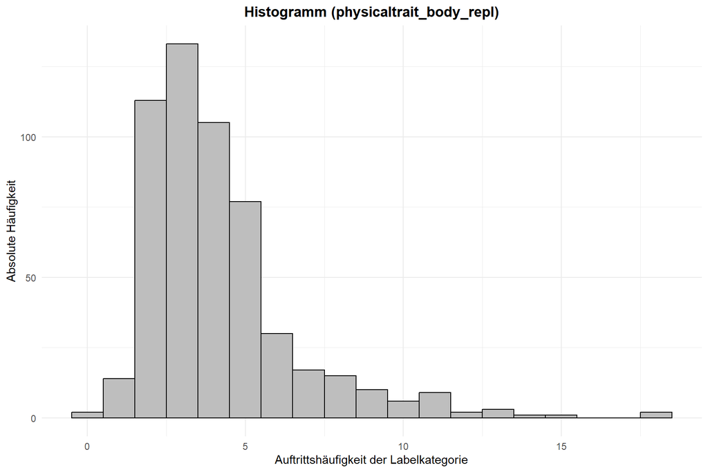

```r
ggplot(merged_df, aes(x = physicaltrait_body_repl)) +
  geom_histogram(binwidth = 1, fill = "grey", color = "black") +
  labs(title = "Histogramm (physicaltrait_body_repl)",
       x = "Auftrittshäufigkeit der Labelkategorie",
       y = "Absolute Häufigkeit") +
  theme_minimal() +
  theme(plot.title = element_text(hjust = 0.5, face = "bold"))
```

```r
ggsave(
 'figures/distribution_physicaltrait_body_repl.png',
 bg="white",
 width = 8,
 height = 6,
 dpi = 300
)
```

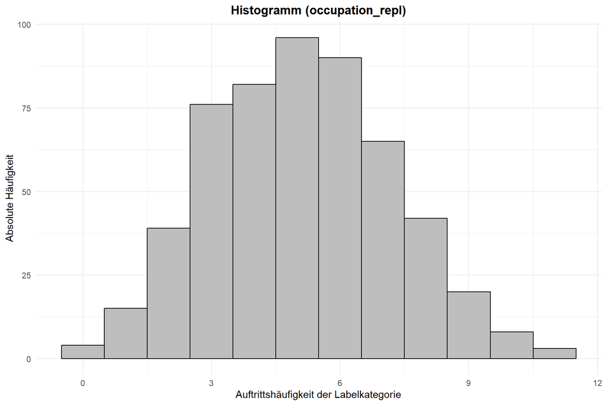

```r
ggplot(merged_df, aes(x = occupation_repl)) +
  geom_histogram(binwidth = 1, fill = "grey", color = "black") +
  labs(title = "Histogramm (occupation_repl)",
       x = "Auftrittshäufigkeit der Labelkategorie",
       y = "Absolute Häufigkeit") +
  theme_minimal() +
  theme(plot.title = element_text(hjust = 0.5, face = "bold"))
```

```r
ggsave(
 'figures/distribution_occupation_repl.png',
 bg="white",
 width = 8,
 height = 6,
 dpi = 300
)
```

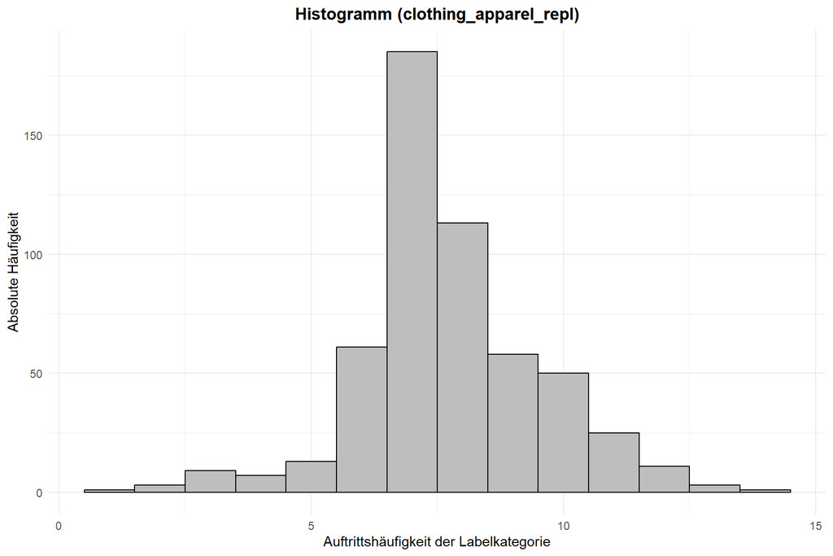

```r
ggplot(merged_df, aes(x = clothing_apparel_repl)) +
  geom_histogram(binwidth = 1, fill = "grey", color = "black") +
  labs(title = "Histogramm (clothing_apparel_repl)",
       x = "Auftrittshäufigkeit der Labelkategorie",
       y = "Absolute Häufigkeit") +
  theme_minimal() +
  theme(plot.title = element_text(hjust = 0.5, face = "bold"))
```

```r
ggsave(
 'figures/distribution_clothing_apparel_repl.png',
 bg="white",
 width = 8,
 height = 6,
 dpi = 300
)
```

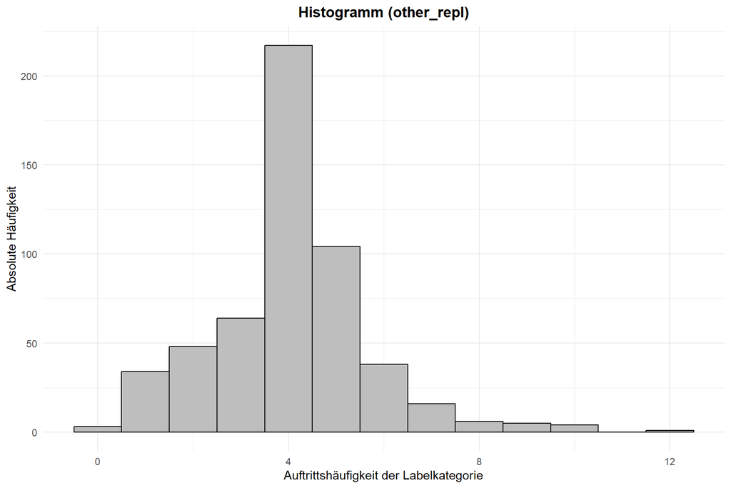

```r
ggplot(merged_df, aes(x = other_repl)) +
  geom_histogram(binwidth = 1, fill = "grey", color = "black") +
  labs(title = "Histogramm (other_repl)",
       x = "Auftrittshäufigkeit der Labelkategorie",
       y = "Absolute Häufigkeit") +
  theme_minimal() +
  theme(plot.title = element_text(hjust = 0.5, face = "bold"))
```

```r
ggsave(
 'figures/distribution_other_repl.png',
 bg="white",
 width = 8,
 height = 6,
 dpi = 300
)
```

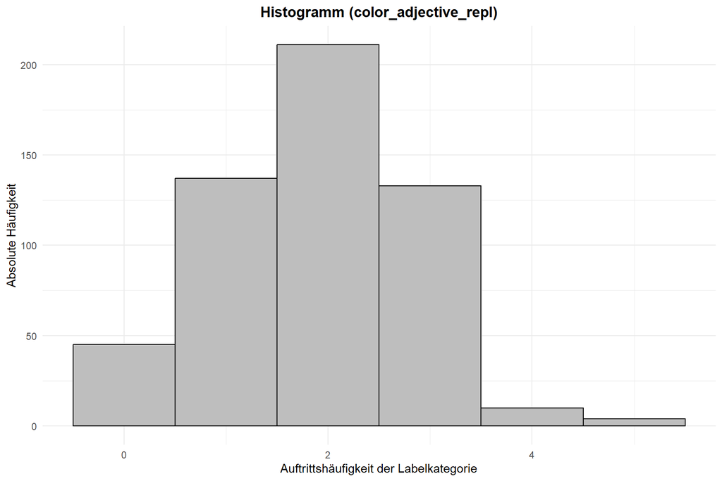

```r
ggplot(merged_df, aes(x = color_adjective_repl)) +
  geom_histogram(binwidth = 1, fill = "grey", color = "black") +
  labs(title = "Histogramm (color_adjective_repl)",
       x = "Auftrittshäufigkeit der Labelkategorie",
       y = "Absolute Häufigkeit") +
  theme_minimal() +
  theme(plot.title = element_text(hjust = 0.5, face = "bold"))
```

```r
ggsave(
 'figures/distribution_color_adjective_repl.png',
 bg="white",
 width = 8,
 height = 6,
 dpi = 300
)
```

## 4.6 Modeling Label Counts

Using poisson & negative binomial regression models, we model category counts and include covariates for age, ethnicity, and party of MCs.

```r
# count for descriptive analysis
mc_df %>% count(ethnicity, sort = TRUE)
```

```
## # A tibble: 7 x 2
##   ethnicity                   n
##   <chr>                   <int>
## 1 white                     428
## 2 african_american           49
## 3 hispanic                   44
## 4 asian                      15
## 5 indian                      2
## 6 african_american, asian     1
## 7 hispanic, asian             1
```

Due to the skewed distribution we only differentiate between “White” and “Non-White” for ethnicity.

```r
mc_df_reg <- merged_df %>% filter(party != "Independent") %>%
                   mutate(gender = as.factor(gender),
                          party = as.factor(party),
                          eth_white = if_else(ethnicity == "white",
                                              "White", "Non-white") %>% as.factor())
# poisson regressions
apparel_poi_repl <- glm(clothing_apparel_repl ~ gender + eth_white + party + age,
                       data = mc_df_reg,
                       family = poisson())
physical_poi_repl <-  glm(physicaltrait_body_repl ~ gender + eth_white  + party  + age,
                       data = mc_df_reg,
                       family = poisson())
occupation_poi_repl <- glm(occupation_repl ~ gender + eth_white + party  + age,
                        data = mc_df_reg,
                        family = poisson())
color_adjective_poi_repl <- glm(color_adjective_repl ~ gender + eth_white + party  + age,
                       data = mc_df_reg,
                       family = poisson())
# unlike the original, "ethnicity" has been replaced by "eth_white"
other_poi_repl <- glm(other_repl ~ gender + eth_white + party  + age,
                       data = mc_df_reg,
                       family = poisson())
```

Check choice of poisson distribution

Set seed = 42 to ensure reproducibility

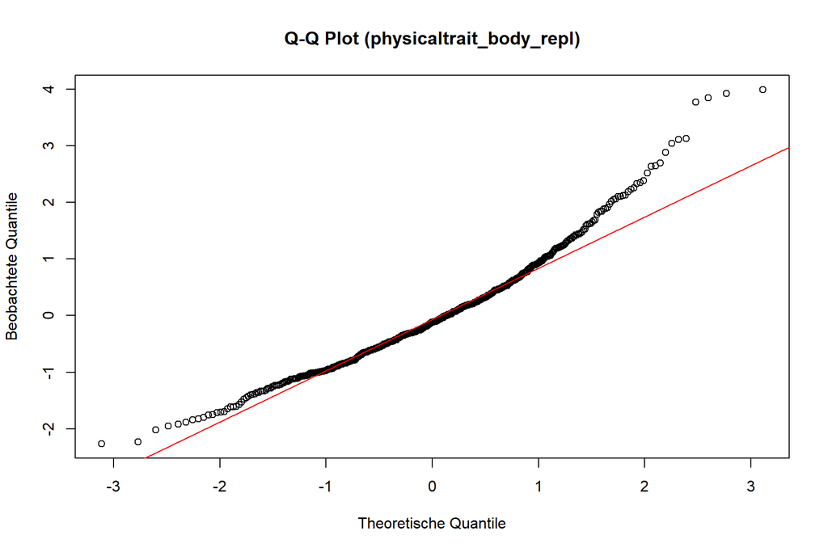

```r
set.seed(42)
qqnorm(qresid(physical_poi_repl),
       main = "Q-Q Plot (physicaltrait_body_repl)",
       xlab = "Theoretische Quantile",
       ylab = "Beobachtete Quantile");
qqline(qresid(physical_poi_repl), col="red")
```

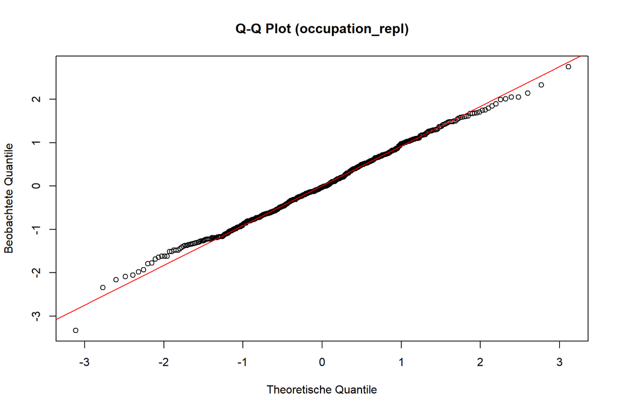

```r
set.seed(42)
qqnorm(qresid(occupation_poi_repl),
       main = "Q-Q Plot (occupation_repl)",
       xlab = "Theoretische Quantile",
       ylab = "Beobachtete Quantile");
qqline(qresid(occupation_poi_repl), col="red")
```

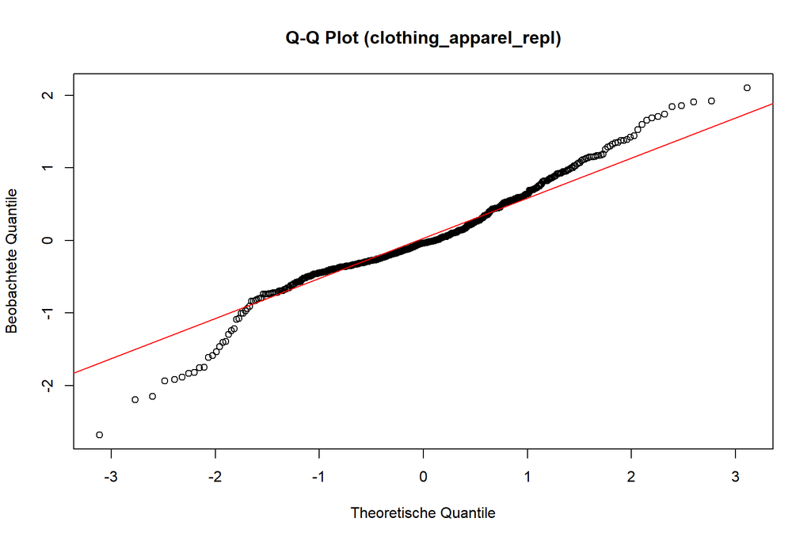

```r
set.seed(42)
qqnorm(qresid(apparel_poi_repl),
       main = "Q-Q Plot (clothing_apparel_repl)",
       xlab = "Theoretische Quantile",
       ylab = "Beobachtete Quantile");
qqline(qresid(apparel_poi_repl), col="red")
```

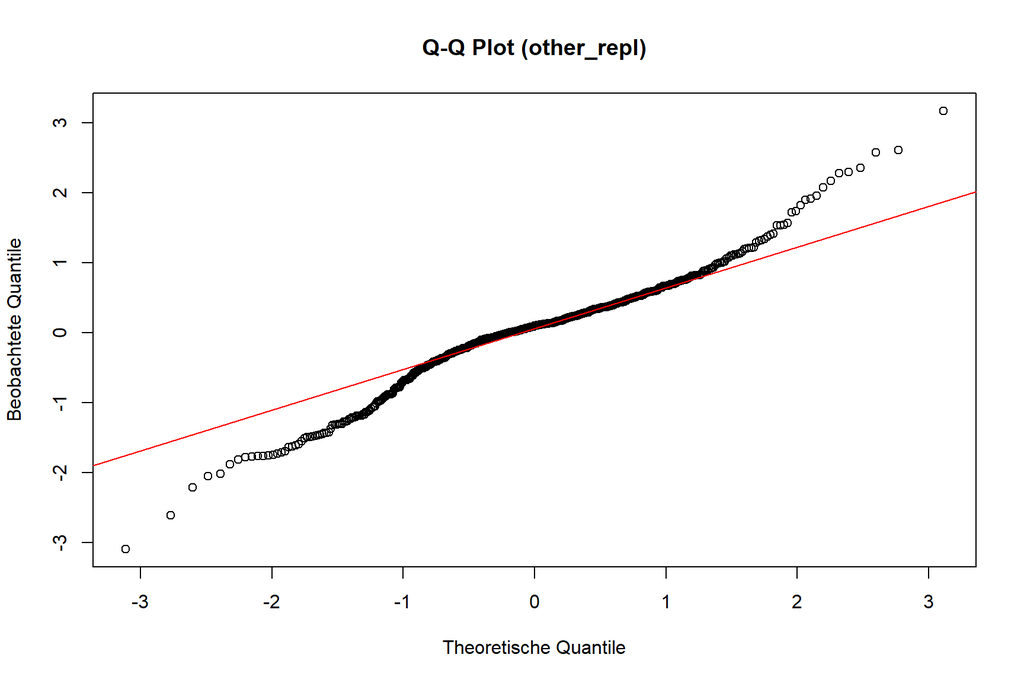

```r
set.seed(42)
qqnorm(qresid(other_poi_repl),
       main = "Q-Q Plot (other_repl)",
       xlab = "Theoretische Quantile",
       ylab = "Beobachtete Quantile");
qqline(qresid(other_poi_repl), col="red")
```

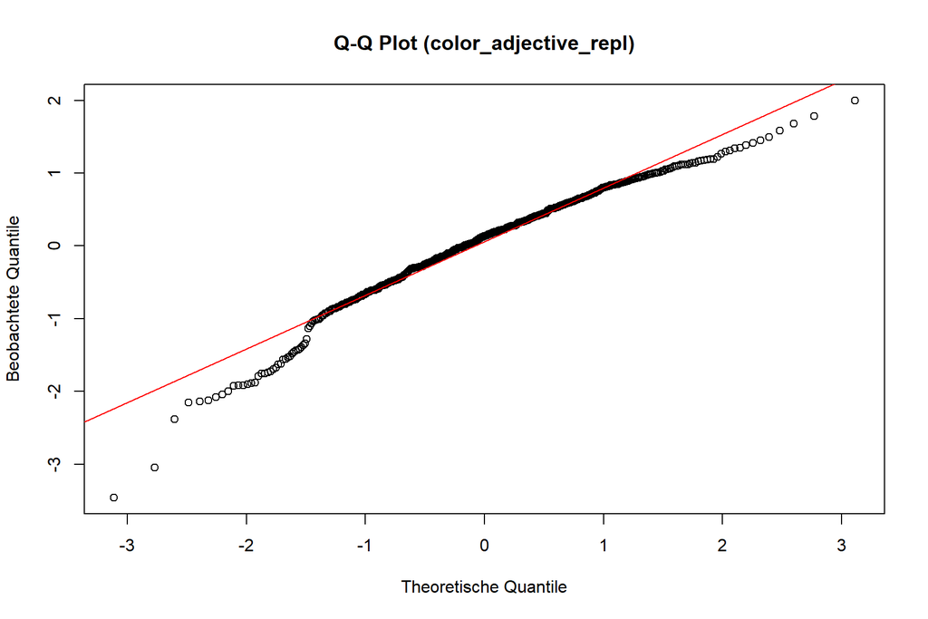

```r
set.seed(42)
qqnorm(qresid(color_adjective_poi_repl),
       main = "Q-Q Plot (color_adjective_repl)",
       xlab = "Theoretische Quantile",
       ylab = "Beobachtete Quantile");
qqline(qresid(color_adjective_poi_repl), col="red")
```

Get overview of poisson regression models

```r
summary(apparel_poi_repl)
```

```
##
## Call:
## glm(formula = clothing_apparel_repl ~ gender + eth_white + party +
##     age, family = poisson(), data = mc_df_reg)
##
## Deviance Residuals:
##     Min       1Q   Median       3Q      Max
## -2.8794  -0.3696  -0.1121   0.3504   2.0676
##
## Coefficients:
##                  Estimate Std. Error z value Pr(>|z|)
## (Intercept)      1.811162   0.099490  18.205   <2e-16 ***
## genderMale       0.096899   0.041655   2.326    0.020 *
## eth_whiteWhite   0.035236   0.042731   0.825    0.410
## partyRepublican -0.005720   0.035273  -0.162    0.871
## age              0.002162   0.001466   1.475    0.140
## ---
## Signif. codes:  0 '***' 0.001 '**' 0.01 '*' 0.05 '.' 0.1 ' ' 1
##
## (Dispersion parameter for poisson family taken to be 1)
##
##     Null deviance: 238.06  on 537  degrees of freedom
## Residual deviance: 228.58  on 533  degrees of freedom
## AIC: 2322.7
##
## Number of Fisher Scoring iterations: 4
```

```r
summary(physical_poi_repl)
```

```
##
## Call:
## glm(formula = physicaltrait_body_repl ~ gender + eth_white +
##     party + age, family = poisson(), data = mc_df_reg)
##
## Deviance Residuals:
##     Min       1Q   Median       3Q      Max
## -2.6005  -0.8969  -0.2764   0.5422   4.0800
##
## Coefficients:
##                  Estimate Std. Error z value Pr(>|z|)
## (Intercept)      1.754509   0.132578  13.234  < 2e-16 ***
## genderMale      -0.404175   0.050361  -8.026 1.01e-15 ***
## eth_whiteWhite   0.174072   0.057479   3.028  0.00246 **
## partyRepublican -0.089546   0.048010  -1.865  0.06216 .
## age             -0.001887   0.001999  -0.944  0.34516
## ---
## Signif. codes:  0 '***' 0.001 '**' 0.01 '*' 0.05 '.' 0.1 ' ' 1
##
## (Dispersion parameter for poisson family taken to be 1)
##
##     Null deviance: 655.24  on 537  degrees of freedom
## Residual deviance: 579.52  on 533  degrees of freedom
## AIC: 2293.5
##
## Number of Fisher Scoring iterations: 5
```

```r
summary(occupation_poi_repl)
```

```
##
## Call:
## glm(formula = occupation_repl ~ gender + eth_white + party +
##     age, family = poisson(), data = mc_df_reg)
##
## Deviance Residuals:
##     Min       1Q   Median       3Q      Max
## -3.4061  -0.6955  -0.0804   0.5790   2.5812
##
## Coefficients:
##                 Estimate Std. Error z value Pr(>|z|)
## (Intercept)      1.69140    0.12187  13.878  < 2e-16 ***
## genderMale       0.38370    0.05603   6.848 7.48e-12 ***
## eth_whiteWhite  -0.11643    0.05186  -2.245  0.02476 *
## partyRepublican  0.06245    0.04372   1.429  0.15313
## age             -0.00537    0.00180  -2.983  0.00285 **
## ---
## Signif. codes:  0 '***' 0.001 '**' 0.01 '*' 0.05 '.' 0.1 ' ' 1
##
## (Dispersion parameter for poisson family taken to be 1)
##
##     Null deviance: 515.65  on 537  degrees of freedom
## Residual deviance: 439.63  on 533  degrees of freedom
## AIC: 2273.3
##
## Number of Fisher Scoring iterations: 4
```

```r
summary(color_adjective_poi_repl)
```

```
##
## Call:
## glm(formula = color_adjective_repl ~ gender + eth_white + party +
##     age, family = poisson(), data = mc_df_reg)
##
## Deviance Residuals:
##     Min       1Q   Median       3Q      Max
## -2.2229  -0.5889   0.1054   0.3633   1.6662
##
## Coefficients:
##                  Estimate Std. Error z value Pr(>|z|)
## (Intercept)      1.188721   0.195228   6.089 1.14e-09 ***
## genderMale      -0.305203   0.076448  -3.992 6.54e-05 ***
## eth_whiteWhite   0.143992   0.085449   1.685   0.0920 .
## partyRepublican -0.068096   0.071217  -0.956   0.3390
## age             -0.006610   0.002965  -2.230   0.0258 *
## ---
## Signif. codes:  0 '***' 0.001 '**' 0.01 '*' 0.05 '.' 0.1 ' ' 1
##
## (Dispersion parameter for poisson family taken to be 1)
##
##     Null deviance: 345.05  on 537  degrees of freedom
## Residual deviance: 323.47  on 533  degrees of freedom
## AIC: 1598.5
##
## Number of Fisher Scoring iterations: 5
```

```r
summary(other_poi_repl)
```

```
##
## Call:
## glm(formula = other_repl ~ gender + eth_white + party + age,
##     family = poisson(), data = mc_df_reg)
##
## Deviance Residuals:
##      Min        1Q    Median        3Q       Max
## -3.14070  -0.45466   0.04439   0.41397   2.96125
##
## Coefficients:
##                  Estimate Std. Error z value Pr(>|z|)
## (Intercept)      1.185165   0.135873   8.723  < 2e-16 ***
## genderMale       0.012103   0.055517   0.218  0.82743
## eth_whiteWhite  -0.157175   0.056372  -2.788  0.00530 **
## partyRepublican  0.013112   0.049072   0.267  0.78932
## age              0.005313   0.002013   2.639  0.00831 **
## ---
## Signif. codes:  0 '***' 0.001 '**' 0.01 '*' 0.05 '.' 0.1 ' ' 1
##
## (Dispersion parameter for poisson family taken to be 1)
##
##     Null deviance: 372.32  on 537  degrees of freedom
## Residual deviance: 357.93  on 533  degrees of freedom
## AIC: 2081.4
##
## Number of Fisher Scoring iterations: 4
```

```r
# dispersion tests
dispersiontest(apparel_poi_repl, trafo = 1)
```

```
##
##  Overdispersion test
##
## data:  apparel_poi_repl
## z = -18.155, p-value = 1
## alternative hypothesis: true alpha is greater than 0
## sample estimates:
##      alpha
## -0.5822218
```

```r
dispersiontest(physical_poi_repl, trafo = 1)
```

```
##
##  Overdispersion test
##
## data:  physical_poi_repl
## z = 1.7152, p-value = 0.04315
## alternative hypothesis: true alpha is greater than 0
## sample estimates:
##     alpha
## 0.1804122
```

```r
dispersiontest(occupation_poi_repl, trafo = 1)
```

```
##
##  Overdispersion test
##
## data:  occupation_poi_repl
## z = -4.6467, p-value = 1
## alternative hypothesis: true alpha is greater than 0
## sample estimates:
##      alpha
## -0.2130192
```

```r
dispersiontest(color_adjective_poi_repl, trafo = 1)
```

```
##
##  Overdispersion test
##
## data:  color_adjective_poi_repl
## z = -14.92, p-value = 1
## alternative hypothesis: true alpha is greater than 0
## sample estimates:
##      alpha
## -0.5176417
```

```r
dispersiontest(other_poi_repl, trafo = 1)
```

```
##
##  Overdispersion test
##
## data:  other_poi_repl
## z = -7.4115, p-value = 1
## alternative hypothesis: true alpha is greater than 0
## sample estimates:
##      alpha
## -0.3797405
```

```r
# run negative binomials instead of poisson due to partial overdisperson
apparel_nb_repl <- glm.nb(clothing_apparel_repl ~ gender + eth_white + party  + age,
                  data = mc_df_reg)

physical_nb_repl <- glm.nb(physicaltrait_body_repl ~ gender + eth_white + party  + age,
                   data = mc_df_reg)

occupation_nb_repl <- glm.nb(occupation_repl ~ gender + eth_white + party  + age,
                     data = mc_df_reg)

color_adjective_nb_repl <- glm.nb(color_adjective_repl ~ gender + eth_white + party  + age,
                          data = mc_df_reg)

other_nb_repl <- glm.nb(other_repl ~ gender + eth_white + party  + age,
                data = mc_df_reg)
```

Get overview of negative binomial regression models

```r
summary(apparel_nb_repl)
```

```
##
## Call:
## glm.nb(formula = clothing_apparel_repl ~ gender + eth_white +
##     party + age, data = mc_df_reg, init.theta = 329167.7995,
##     link = log)
##
## Deviance Residuals:
##     Min       1Q   Median       3Q      Max
## -2.8793  -0.3696  -0.1121   0.3504   2.0675
##
## Coefficients:
##                  Estimate Std. Error z value Pr(>|z|)
## (Intercept)      1.811163   0.099491  18.204   <2e-16 ***
## genderMale       0.096899   0.041655   2.326    0.020 *
## eth_whiteWhite   0.035236   0.042731   0.825    0.410
## partyRepublican -0.005720   0.035273  -0.162    0.871
## age              0.002162   0.001466   1.475    0.140
## ---
## Signif. codes:  0 '***' 0.001 '**' 0.01 '*' 0.05 '.' 0.1 ' ' 1
##
## (Dispersion parameter for Negative Binomial(329167.8) family taken to be 1)
##
##     Null deviance: 238.06  on 537  degrees of freedom
## Residual deviance: 228.57  on 533  degrees of freedom
## AIC: 2324.7
##
## Number of Fisher Scoring iterations: 1
##
##
##               Theta:  329168
##           Std. Err.:  2070337
## Warning while fitting theta: iteration limit reached
##
##  2 x log-likelihood:  -2312.688
```

```r
summary(physical_nb_repl)
```

```
##
## Call:
## glm.nb(formula = physicaltrait_body_repl ~ gender + eth_white +
##     party + age, data = mc_df_reg, init.theta = 22.53080312,
##     link = log)
##
## Deviance Residuals:
##     Min       1Q   Median       3Q      Max
## -2.5169  -0.8278  -0.2443   0.4997   3.5543
##
## Coefficients:
##                  Estimate Std. Error z value Pr(>|z|)
## (Intercept)      1.749716   0.144840  12.080  < 2e-16 ***
## genderMale      -0.401209   0.055737  -7.198  6.1e-13 ***
## eth_whiteWhite   0.169859   0.062693   2.709  0.00674 **
## partyRepublican -0.090789   0.052382  -1.733  0.08306 .
## age             -0.001779   0.002179  -0.816  0.41447
## ---
## Signif. codes:  0 '***' 0.001 '**' 0.01 '*' 0.05 '.' 0.1 ' ' 1
##
## (Dispersion parameter for Negative Binomial(22.5308) family taken to be 1)
##
##     Null deviance: 541.06  on 537  degrees of freedom
## Residual deviance: 478.23  on 533  degrees of freedom
## AIC: 2283.8
##
## Number of Fisher Scoring iterations: 1
##
##
##               Theta:  22.53
##           Std. Err.:  7.65
##
##  2 x log-likelihood:  -2271.779
```

```r
summary(occupation_nb_repl)
```

```
##
## Call:
## glm.nb(formula = occupation_repl ~ gender + eth_white + party +
##     age, data = mc_df_reg, init.theta = 92361.58223, link = log)
##
## Deviance Residuals:
##     Min       1Q   Median       3Q      Max
## -3.4060  -0.6955  -0.0804   0.5790   2.5811
##
## Coefficients:
##                 Estimate Std. Error z value Pr(>|z|)
## (Intercept)      1.69140    0.12188  13.878  < 2e-16 ***
## genderMale       0.38370    0.05603   6.848  7.5e-12 ***
## eth_whiteWhite  -0.11643    0.05186  -2.245  0.02476 *
## partyRepublican  0.06245    0.04372   1.429  0.15314
## age             -0.00537    0.00180  -2.983  0.00285 **
## ---
## Signif. codes:  0 '***' 0.001 '**' 0.01 '*' 0.05 '.' 0.1 ' ' 1
##
## (Dispersion parameter for Negative Binomial(92361.58) family taken to be 1)
##
##     Null deviance: 515.62  on 537  degrees of freedom
## Residual deviance: 439.61  on 533  degrees of freedom
## AIC: 2275.3
##
## Number of Fisher Scoring iterations: 1
##
##
##               Theta:  92362
##           Std. Err.:  585735
## Warning while fitting theta: iteration limit reached
##
##  2 x log-likelihood:  -2263.276
```

```r
summary(color_adjective_nb_repl)
```

```
##
## Call:
## glm.nb(formula = color_adjective_repl ~ gender + eth_white +
##     party + age, data = mc_df_reg, init.theta = 68598.13161,
##     link = log)
##
## Deviance Residuals:
##     Min       1Q   Median       3Q      Max
## -2.2229  -0.5889   0.1054   0.3633   1.6662
##
## Coefficients:
##                  Estimate Std. Error z value Pr(>|z|)
## (Intercept)      1.188723   0.195231   6.089 1.14e-09 ***
## genderMale      -0.305203   0.076449  -3.992 6.55e-05 ***
## eth_whiteWhite   0.143992   0.085450   1.685   0.0920 .
## partyRepublican -0.068095   0.071218  -0.956   0.3390
## age             -0.006610   0.002965  -2.230   0.0258 *
## ---
## Signif. codes:  0 '***' 0.001 '**' 0.01 '*' 0.05 '.' 0.1 ' ' 1
##
## (Dispersion parameter for Negative Binomial(68598.13) family taken to be 1)
##
##     Null deviance: 345.05  on 537  degrees of freedom
## Residual deviance: 323.47  on 533  degrees of freedom
## AIC: 1600.5
##
## Number of Fisher Scoring iterations: 1
##
##
##               Theta:  68598
##           Std. Err.:  421934
## Warning while fitting theta: iteration limit reached
##
##  2 x log-likelihood:  -1588.478
```

```r
summary(other_nb_repl)
```

```
##
## Call:
## glm.nb(formula = other_repl ~ gender + eth_white + party + age,
##     data = mc_df_reg, init.theta = 111160.1639, link = log)
##
## Deviance Residuals:
##      Min        1Q    Median        3Q       Max
## -3.14066  -0.45465   0.04439   0.41397   2.96117
##
## Coefficients:
##                  Estimate Std. Error z value Pr(>|z|)
## (Intercept)      1.185165   0.135876   8.722  < 2e-16 ***
## genderMale       0.012103   0.055518   0.218  0.82743
## eth_whiteWhite  -0.157175   0.056374  -2.788  0.00530 **
## partyRepublican  0.013111   0.049073   0.267  0.78933
## age              0.005313   0.002013   2.639  0.00831 **
## ---
## Signif. codes:  0 '***' 0.001 '**' 0.01 '*' 0.05 '.' 0.1 ' ' 1
##
## (Dispersion parameter for Negative Binomial(111160.2) family taken to be 1)
##
##     Null deviance: 372.31  on 537  degrees of freedom
## Residual deviance: 357.92  on 533  degrees of freedom
## AIC: 2083.4
##
## Number of Fisher Scoring iterations: 1
##
##
##               Theta:  111160
##           Std. Err.:  707814
## Warning while fitting theta: iteration limit reached
##
##  2 x log-likelihood:  -2071.364
```

Now we combine all estimates and visualize effect estimates for different covariates, while holding other respective covariates at their observed values.

```r
pred_apparel <- ggeffect(apparel_poi_repl)
pred_apparel$age <- pred_apparel$age %>% mutate(x = as.character(x))
pred_apparel <- pred_apparel %>% plyr::ldply(., data.frame) %>%
  mutate(cat = "clothing / apparel")

pred_physical <- ggeffect(physical_nb_repl)
pred_physical$age <- pred_physical$age %>% mutate(x = as.character(x))
pred_physical <- pred_physical %>% plyr::ldply(., data.frame) %>%
  mutate(cat = "physical trait / body")


pred_occupation <- ggeffect(occupation_poi_repl)
pred_occupation$age <- pred_occupation$age %>% mutate(x = as.character(x))
pred_occupation <- pred_occupation %>% plyr::ldply(., data.frame) %>%
  mutate(cat = "occupation")


pred_color <- ggeffect(color_adjective_poi_repl)
pred_color$age <- pred_color$age %>% mutate(x = as.character(x))
pred_color <- pred_color %>% plyr::ldply(., data.frame) %>%
  mutate(cat = "color / adjective")


pred_other <- ggeffect(other_poi_repl)
pred_other$age <- pred_other$age %>% mutate(x = as.character(x))
pred_other <- pred_other %>% plyr::ldply(., data.frame) %>%
  mutate(cat = "other")

all_preds = list(pred_apparel,
                 pred_physical,
                 pred_occupation,
                 pred_color,
                 pred_other) %>%
  plyr::ldply(., data.frame) %>%
  rename(label = x, indicator = group)
```

The following code creates the average predicted category counts conditional on gender:

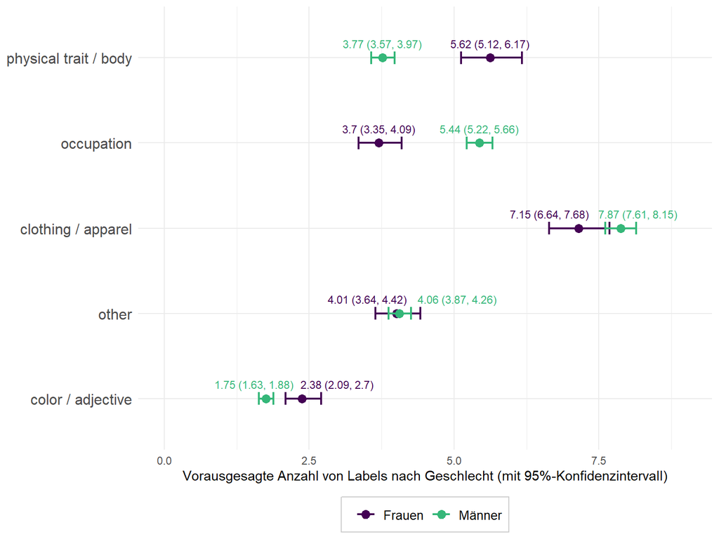

```r
# individual lateral spacing for each category
nudge_values <- c(c(-0.5, 0.3), c(0, 0), c(0, 0), c(0.6, -0.2), c(-0.5, 1))

all_preds %>%
  filter(indicator == "gender") %>%
  ggplot(aes(
    x = predicted,
    y =  reorder(cat, predicted),
    color = label,
    group = 1
  )) +
  geom_point(size = 3) +
  scale_color_manual(values = viridis(n = 4)[c(1, 3)],
                     name = NULL,
                     labels = c("Frauen", "Männer"))  +
  scale_x_continuous(limits = c(0, 9)) +
  geom_errorbarh(aes(
    xmin = conf.low,
    xmax = conf.high,
    height = 0.15
  ), size = 0.75) +
geom_text(aes(label = paste(round(predicted, 2), " ", "(", round(conf.low, 2) , ", ", round(conf.high, 2), ")", sep = "")),
            vjust = -1.2, size = 3, position = position_nudge(x = nudge_values)) +
  #  scale_shape_manual(values=c(19, 15))+
  scale_y_discrete(
    limits = c(
      "color / adjective",
      "other",
      "clothing / apparel",
      "occupation",
      "physical trait / body"
    )
  ) +
  labs(x = "Vorausgesagte Anzahl von Labels nach Geschlecht (mit 95%-Konfidenzintervall)", y = "label category",
       color = "gender") +
  theme_minimal() +
  theme(
    legend.position = "bottom",
    legend.box.background = element_rect(colour = "grey80"),
    legend.text = element_text(size = 10),
    axis.text.x = element_text(angle = 0),
    axis.text.y = element_text(size = 12),
    strip.text.x = element_text(size = 12),
    axis.title.y = element_blank(),
    plot.title = element_text(size = 14, face = "bold", hjust = 0.5),
    plot.caption = element_text(size = 9, face = "italic")
  )
```

```r
ggsave(
 'figures/predicted_category_counts_repl.png',
 bg="white",
 dpi = 300,
 width = 8,
 height = 6
)
```

```r
# get well formatted regression tables
# select the appropriate model in each case

# original
stargazer(physical, occupation, apparel, other, color_adjective,
          style = "default",
          model.names   = TRUE,
          out = "tables/reg_table_original.html")

# replication
stargazer(physical_nb_repl, occupation_poi_repl, apparel_poi_repl, other_poi_repl, color_adjective_poi_repl,
          style = "default",
          out = "tables/reg_table_repl.html")
```